# LTEM Database checking

Published

2023-03-31

# 1 Amphibians

## 1.1 Years when each study area was surveyed

```
Number of records in each study area x year combination
```

```
                      Year
STUDY_AREA_NAME_shrt   2013 2014 2015 2016 2017 2018 2019 2020 2021 Sum
  Alice Lake Park         0    0    9   13    0    8    0    5    0  35
  Big Bar Lake Park       0    0    3    0    0    5    7    1   25  41
  Bowron Lakes Park       0    0    1    0    0    0    0    0    0   1
  Brandywine Falls Par    0    0    4    2    0    1    0   13    0  20
  Burges James Gadsden    0    0    4    5   17   30    6   14    0  76
  Call Lake Park          0    0    8    3    3    1    1    2    0  18
  Champion Lakes Park     0    0    0   13   11    5    0    1   17  47
  Hai Lake-Mount Herma    0    0    7   14   14   18   22   10    8  93
  Lac du Bois Protecte    0    0    4    0    0    0    0    3    4  11
  Mahoney Lake Ecologi    0    0    0    2    0   12    6   11    0  31
  Misty Lake Ecologica    0    1    4    5    2    2    3    0    0  17
  Naikoon Park            0    0    4    0    7    6    4    0    0  21
  Nazko Lake Park         0    0   10    0    0    2    1    0    0  13
  Sutton Pass Ecologic    0    0    0    0    3    0    0    3    0   6
  Wells Gray Park         0    0    0    0    0   13    6    7    0  26
  White Lake Park         0    0    0    0    0    9    2    0    1  12
  Yellow Point Bog Eco    5    8    4    5    4    4    2    3   56  91
```

I don’t understand why there are some sites with a large number of records (20+) and some with small numbers of records (1). On each transects, some basic information is supposed to be recorded.

**This appears to be an artefact of multiple types of transects (audio or visual) x multiple transects run each year. For example, Hai Lake in 2018 has both audio and visual transects run 9 times over the season (see below)

## 1.2 Number of distinct transects run in each study area.year combination

The number of unique transect names run in each study area.year combination is:

```
                      Year
STUDY_AREA_NAME_shrt   2013 2014 2015 2016 2017 2018 2019 2020 2021
  Alice Lake Park         0    0    1    1    0    1    0    1    0
  Big Bar Lake Park       0    0    1    0    0    1    1    1    1
  Bowron Lakes Park       0    0    1    0    0    0    0    0    0
  Brandywine Falls Par    0    0    1    1    0    1    0    1    0
  Burges James Gadsden    0    0    1    1    1    1    1    1    0
  Call Lake Park          0    0    1    1    1    1    1    1    0
  Champion Lakes Park     0    0    0    1    1    1    0    1    1
  Hai Lake-Mount Herma    0    0    1    2    2    2    2    2    1
  Lac du Bois Protecte    0    0    1    0    0    0    0    1    1
  Mahoney Lake Ecologi    0    0    0    1    0    3    2    2    0
  Misty Lake Ecologica    0    1    1    1    1    1    1    0    0
  Naikoon Park            0    0    1    0    1    1    1    0    0
  Nazko Lake Park         0    0    1    0    0    1    1    0    0
  Sutton Pass Ecologic    0    0    0    0    1    0    0    1    0
  Wells Gray Park         0    0    0    0    0    3    1    1    0
  White Lake Park         0    0    0    0    0    1    1    0    1
  Yellow Point Bog Eco    3    3    2    2    2    2    2    2    3
```

We see that, for example, Hai Lake has 2 different transect names in 2016-2020. When the data is examined more closely, these correspond to a visual and an auditory survey. A summary of the unique transect names where there is more than one of them is:

```
    STUDY_AREA_NAME_shrt Year                                         TRANSECT
144 Hai Lake-Mount Herma 2016                                  Auditory survey
197 Hai Lake-Mount Herma 2016                                    Visual survey
146 Hai Lake-Mount Herma 2017                                  Auditory survey
191 Hai Lake-Mount Herma 2017                                    Visual survey
142 Hai Lake-Mount Herma 2018                                  Auditory survey
194 Hai Lake-Mount Herma 2018                                    Visual survey
159 Hai Lake-Mount Herma 2019                                  Auditory survey
189 Hai Lake-Mount Herma 2019                                    Visual survey
150 Hai Lake-Mount Herma 2020                                  Auditory survey
192 Hai Lake-Mount Herma 2020                                    Visual survey
238 Mahoney Lake Ecologi 2018             Auditory survey #1 SW corner of lake
416 Mahoney Lake Ecologi 2018 Auditory survey #2 Interpretive sign E edge lake
427 Mahoney Lake Ecologi 2018                                    Visual survey
236 Mahoney Lake Ecologi 2019             Auditory survey #1 SW corner of lake
```

[output cut: 27 more lines]

We see, for example, that Hai Lake has both auditory and visual surveys. Mahoney Lake has 2 different auditory surveys plus a visual survey in some years.

## 1.3 Number of survey dates

In some cases, there are more than one survey date

```
                      Year
STUDY_AREA_NAME_shrt   2013 2014 2015 2016 2017 2018 2019 2020 2021
  Alice Lake Park         0    0    1    1    0    1    0    1    0
  Big Bar Lake Park       0    0    1    0    0    1    1    1    1
  Bowron Lakes Park       0    0    1    0    0    0    0    0    0
  Brandywine Falls Par    0    0    1    1    0    1    0    1    0
  Burges James Gadsden    0    0    1    1    1    1    2    1    0
  Call Lake Park          0    0    1    1    1    1    1    1    0
  Champion Lakes Park     0    0    0    2    2    2    0    1    1
  Hai Lake-Mount Herma    0    0    5    7    6    5    6    3    3
  Lac du Bois Protecte    0    0    1    0    0    0    0    2    2
  Mahoney Lake Ecologi    0    0    0    1    0    3    3    5    0
  Misty Lake Ecologica    0    1    2    1    1    1    1    0    0
  Naikoon Park            0    0    1    0    2    3    2    0    0
  Nazko Lake Park         0    0    1    0    0    2    1    0    0
  Sutton Pass Ecologic    0    0    0    0    1    0    0    3    0
  Wells Gray Park         0    0    0    0    0    5    2    3    0
  White Lake Park         0    0    0    0    0    2    1    0    1
  Yellow Point Bog Eco    1    1    1    1    1    1    1    1   44
```

```
    STUDY_AREA_NAME_shrt Year                                         TRANSECT       Date
9   Burges James Gadsden 2019                        Burges James Gadsden Park 2019-06-04
1   Burges James Gadsden 2019                        Burges James Gadsden Park 2019-06-18
99   Champion Lakes Park 2016                              Champion Lakes Park 2016-04-28
96   Champion Lakes Park 2016                              Champion Lakes Park 2016-05-13
114  Champion Lakes Park 2017                              Champion Lakes Park 2017-05-10
109  Champion Lakes Park 2017                              Champion Lakes Park 2017-06-17
139  Champion Lakes Park 2018                              Champion Lakes Park 2018-05-11
102  Champion Lakes Park 2018                              Champion Lakes Park 2018-06-12
206 Hai Lake-Mount Herma 2015                                    Visual survey 2015-05-17
200 Hai Lake-Mount Herma 2015                                    Visual survey 2015-07-10
234 Hai Lake-Mount Herma 2015                                    Visual survey 2015-08-11
203 Hai Lake-Mount Herma 2015                                    Visual survey 2015-09-02
190 Hai Lake-Mount Herma 2015                                    Visual survey 2015-09-29
162 Hai Lake-Mount Herma 2016                                  Auditory survey 2016-03-14
```

[output cut: 160 more lines]

## 1.4 Version Number of the database

This is important because the fields containing the data vary by version numbers:

```
                      VERSION_NO
STUDY_AREA_NAME_shrt   1.29999995231628 1.39999997615814
  Alice Lake Park                    30                5
  Big Bar Lake Park                  15               26
  Bowron Lakes Park                   1                0
  Brandywine Falls Par                4               16
  Burges James Gadsden               76                0
  Call Lake Park                     18                0
  Champion Lakes Park                29               18
  Hai Lake-Mount Herma               85                8
  Lac du Bois Protecte                7                4
  Mahoney Lake Ecologi               20               11
  Misty Lake Ecologica               17                0
  Naikoon Park                       21                0
  Nazko Lake Park                    12                1
  Sutton Pass Ecologic                6                0
  Wells Gray Park                    26                0
  White Lake Park                    11                1
  Yellow Point Bog Eco               35               56
```

## 1.5 Dump of information to see which fields are important

```
    STUDY_AREA_NAME_shrt Year                                         TRANSECT SPECIES_CODE EggMasses Adults VERSION_NO A16 A17  A18  A26 A14 A15 A16.1  A24
365      Alice Lake Park 2015                               Fawn Lake Transect       A-AMGR        NA     NA        1.3  NA  NA   NA <NA>  NA  NA    NA <NA>
349      Alice Lake Park 2015                               Fawn Lake Transect       A-ANBO        NA      1        1.3  NA  NA    1 <NA>  NA  NA    NA <NA>
359      Alice Lake Park 2015                               Fawn Lake Transect       A-ANBO        NA     NA        1.3  NA  NA   NA <NA>  NA  NA    NA <NA>
376      Alice Lake Park 2015                               Fawn Lake Transect       A-ANBO        NA     10        1.3  NA  NA   10 <NA>  NA  NA    NA <NA>
381      Alice Lake Park 2015                               Fawn Lake Transect       A-ANBO        NA      5        1.3  NA  NA    5 <NA>  NA  NA    NA <NA>
348      Alice Lake Park 2015                               Fawn Lake Transect       A-PSRE        NA      1        1.3  NA  NA    1 <NA>  NA  NA    NA <NA>
378      Alice Lake Park 2015                               Fawn Lake Transect       A-PSRE        NA     NA        1.3  NA  NA   NA <NA>  NA  NA    NA <NA>
379      Alice Lake Park 2015                               Fawn Lake Transect       A-RAAU        NA     NA        1.3  NA  NA   NA <NA>  NA  NA    NA <NA>
366      Alice Lake Park 2015                               Fawn Lake Transect     AMPHIBIA        NA     NA        1.3  NA  NA   NA <NA>  NA  NA    NA <NA>
370      Alice Lake Park 2016                               Fawn Lake Transect       A-AMGR         8     NA        1.3  NA  NA   NA    8  NA  NA    NA <NA>
354      Alice Lake Park 2016                               Fawn Lake Transect       A-ANBO        NA     NA        1.3  NA  NA   NA <NA>  NA  NA    NA <NA>
357      Alice Lake Park 2016                               Fawn Lake Transect       A-ANBO        NA     NA        1.3  NA  NA   NA <NA>  NA  NA    NA <NA>
367      Alice Lake Park 2016                               Fawn Lake Transect       A-ANBO        NA     NA        1.3  NA  NA   NA <NA>  NA  NA    NA <NA>
369      Alice Lake Park 2016                               Fawn Lake Transect       A-ANBO        NA     NA        1.3  NA  NA   NA <NA>  NA  NA    NA <NA>
```

[output cut: 545 more lines]

## 1.6 Missing lat/long information

The Ecodomain of each study area was obtained by looking up the mean latitude/longitude of observations for each STUDY_AREA in the Ecoprovices provided in the *bcmaps* package. In some cases, latitude/longitude is not available for a record. This needs to be added to the record

```
Total records missing lat/long is  0
```

```
Tabulation of where missing lat/long occurs
```

```
< table of extent 0 x 0 >
```

## 1.7 Missing ECODOMAIN

The classification of each remaining STUDY_AREA into its EcoDomain is:

```
Site missing long/lat data so ecodomain could not be determined
```

```
[1] STUDY_AREA_NAME_shrt LONGITUDE_DD         LATITUDE_DD
<0 rows> (or 0-length row.names)
```

```
                      ECODOMAIN
STUDY_AREA_NAME_shrt   CoastMtn HumConHigh SemiAridHigh
  Alice Lake Park             1          0            0
  Big Bar Lake Park           0          1            0
  Bowron Lakes Park           0          1            0
  Brandywine Falls Par        1          0            0
  Burges James Gadsden        0          1            0
  Call Lake Park              0          1            0
  Champion Lakes Park         0          1            0
  Hai Lake-Mount Herma        1          0            0
  Lac du Bois Protecte        0          0            1
  Mahoney Lake Ecologi        0          0            1
  Misty Lake Ecologica        1          0            0
  Naikoon Park                1          0            0
  Nazko Lake Park             0          1            0
  Sutton Pass Ecologic        1          0            0
  Wells Gray Park             0          1            0
  White Lake Park             0          1            0
  Yellow Point Bog Eco        1          0            0
```

## 1.8 Checking species code

### 1.8.1 Which species codes are present?

The species code should be the same across for all data values.

```
            Year
SPECIES_CODE 2013 2014 2015 2016 2017 2018 2019 2020 2021
    A-AMGR      0    2    7    6    5    4    2    6    4
    A-AMMA      0    0    0    2    0    0    0    8    0
    A-ANBO      0    0   17    9    5   10    8    8    4
    A-LICA      2    2    2    0    0    1    0    0   14
    A-LISY      0    0    0    0    1    0    0    0    0
    A-PSRE      1    3    5   13   20   20   12   13   30
    A-RAAU      0    1    3    4    3    3    2    6    0
    A-RALU      0    0   12   11   10    9    4    5   46
    A-SPIN      0    0    0    1    0    6    1    1    0
    A-TAGR      0    0    0    0    0    0    0    0    1
    AMPHIBIA    2    0    4    3    0   42   13   15    3
    NULL        0    1   12   13   17   21   18   11    9
```

In some cases, species is NULL and in some cases species is AMPHIBIA. Does NULL species indicate zeros?

### 1.8.2 Records with NULL species codes

Data records with missing species codes

```
[1] TRUE TRUE TRUE TRUE TRUE TRUE
```

```
    STUDY_AREA_NAME_shrt Year SPECIES_CODE                             TRANSECT EggMasses Adults
187       Call Lake Park 2017         NULL                       Call Lake Park        NA     NA
188       Call Lake Park 2018         NULL                       Call Lake Park        NA     NA
213  Champion Lakes Park 2017         NULL                  Champion Lakes Park        NA      0
214  Champion Lakes Park 2017         NULL                  Champion Lakes Park        NA      0
215  Champion Lakes Park 2017         NULL                  Champion Lakes Park        NA     NA
239 Hai Lake-Mount Herma 2015         NULL                        Visual survey        NA     NA
240 Hai Lake-Mount Herma 2015         NULL                        Visual survey        NA     NA
241 Hai Lake-Mount Herma 2015         NULL                        Visual survey        NA     NA
242 Hai Lake-Mount Herma 2015         NULL                        Visual survey        NA     NA
243 Hai Lake-Mount Herma 2015         NULL                        Visual survey        NA     NA
244 Hai Lake-Mount Herma 2015         NULL                        Visual survey        NA     NA
245 Hai Lake-Mount Herma 2015         NULL                        Visual survey        NA     NA
246 Hai Lake-Mount Herma 2016         NULL                      Auditory survey        NA     NA
247 Hai Lake-Mount Herma 2016         NULL                      Auditory survey        NA     NA
```

[output cut: 88 more lines]

Does this indicate NO eggmasses and adults seen? Why are there multiple records for some study areax year combinations?

### 1.8.3 Where do AMPHIBIA species occur?

Tabulation of where AMPHIBI species measured

```
Where AMPIBIIA species measured
```

```
                      Year
STUDY_AREA_NAME_shrt   2013 2014 2015 2016 2017 2018 2019 2020 2021
  Alice Lake Park         0    0    8   12    0    5    0    5    0
  Big Bar Lake Park       0    0    3    0    0    4    2    1   25
  Brandywine Falls Par    0    0    4    2    0    1    0   13    0
  Burges James Gadsden    0    0    3    5   17    0    2    0    0
  Call Lake Park          0    0    8    2    3    1    1    2    0
  Champion Lakes Park     0    0    0   13   11    5    0    1   17
  Hai Lake-Mount Herma    0    0    7   14   14   18   22   10    6
  Lac du Bois Protecte    0    0    3    0    0    0    0    3    3
  Mahoney Lake Ecologi    0    0    0    2    0   12    6   11    0
  Misty Lake Ecologica    0    1    4    5    2    2    3    0    0
  Naikoon Park            0    0    4    0    7    6    4    0    0
  Nazko Lake Park         0    0   10    0    0    2    0    0    0
  Sutton Pass Ecologic    0    0    0    0    3    0    0    2    0
  Wells Gray Park         0    0    0    0    0    9    3    7    0
  White Lake Park         0    0    0    0    0    5    2    0    1
  Yellow Point Bog Eco    3    8    4    4    4    4    2    3   56
```

Appears to occur inconsistently across the study areas.

## 1.9 Transect

The protocol is supposed to have transect(s) with auditory and/or visual counts. It appears that in some cases, the transect name is the type of survey?

```
                                           TRANSECT Freq
1                                        Alice Lake   16
2                                   Auditory survey   47
3              Auditory survey #1 SW corner of lake   14
4  Auditory survey #2 Interpretive sign E edge lake   13
5                         Burges James Gadsden Park   76
6                                    Call Lake Park   18
7                               Champion Lakes Park   47
8                                Fawn Lake Transect   35
9                                Lava Lake Transect   20
10              Listening station (auditory survey)   18
11                    Misty Lake Ecological Reserve   17
12                                     Naikoon Park   21
13                                  Nazko Lake Park   13
14                                     Opax wetland   11
15                                       Otter Lake   41
16                                      Shadow Lake    8
17                               Station 1 (visual)   13
18                               Station 2 (visual)   60
19                   Sutton Pass Ecological Reserve    6
20                                   Swan/Spectacle    1
21                                    Visual survey   50
22                                        West Lake    2
23                                  White Lake Park   12
```

```
                      TRANSECT
STUDY_AREA_NAME_shrt   Auditory survey Auditory survey #1 SW corner of lake Auditory survey #2 Interpretive sign E edge lake Listening station (auditory survey) Station 1 (visual) Station 2 (visual)
  Hai Lake-Mount Herma              47                                    0                                                0                                   0                  0                  0
  Mahoney Lake Ecologi               0                                   14                                               13                                   0                  0                  0
  Yellow Point Bog Eco               0                                    0                                                0                                  18                 13                 60
                      TRANSECT
STUDY_AREA_NAME_shrt   Visual survey
  Hai Lake-Mount Herma            46
  Mahoney Lake Ecologi             4
  Yellow Point Bog Eco             0
```

## 1.10 Missing eggmass data or adult counts when species code recorded

If a species code is present, the number of eggmasses should be recorded.

```
    STUDY_AREA_NAME_shrt Year SPECIES_CODE                                         TRANSECT EggMasses Adults
1        Alice Lake Park 2015       A-AMGR                               Fawn Lake Transect        NA     NA
2        Alice Lake Park 2015       A-ANBO                               Fawn Lake Transect        NA      1
3        Alice Lake Park 2015       A-ANBO                               Fawn Lake Transect        NA     NA
4        Alice Lake Park 2015       A-ANBO                               Fawn Lake Transect        NA     10
5        Alice Lake Park 2015       A-ANBO                               Fawn Lake Transect        NA      5
6        Alice Lake Park 2015       A-PSRE                               Fawn Lake Transect        NA      1
7        Alice Lake Park 2015       A-PSRE                               Fawn Lake Transect        NA     NA
8        Alice Lake Park 2015       A-RAAU                               Fawn Lake Transect        NA     NA
9        Alice Lake Park 2015     AMPHIBIA                               Fawn Lake Transect        NA     NA
10       Alice Lake Park 2016       A-AMGR                               Fawn Lake Transect         8     NA
11       Alice Lake Park 2016       A-ANBO                               Fawn Lake Transect        NA     NA
12       Alice Lake Park 2016       A-ANBO                               Fawn Lake Transect        NA     NA
13       Alice Lake Park 2016       A-ANBO                               Fawn Lake Transect        NA     NA
14       Alice Lake Park 2016       A-ANBO                               Fawn Lake Transect        NA     NA
```

[output cut: 443 more lines]

## 1.11 Distribution of eggmass data

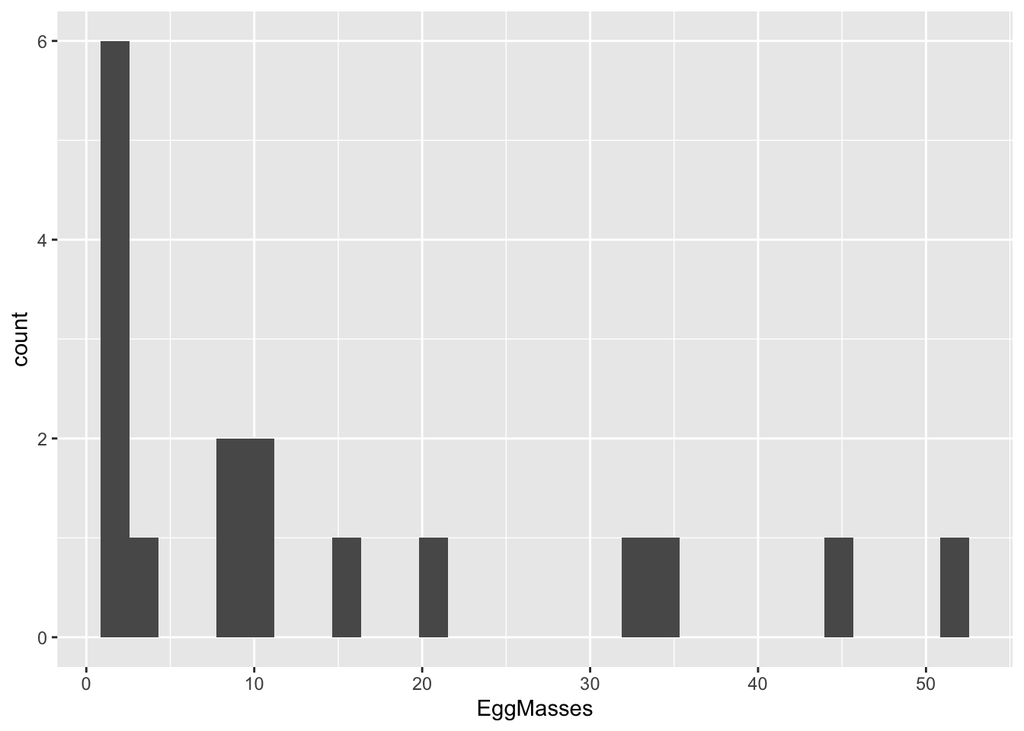

```
EggMasses
   1    2    3    8   10   15   20   33   35   45   51 <NA>
   5    1    1    2    2    1    1    1    1    1    1  542
```

# 2 Check the large values for EggMasses

## 2.1 Distribution of adults data

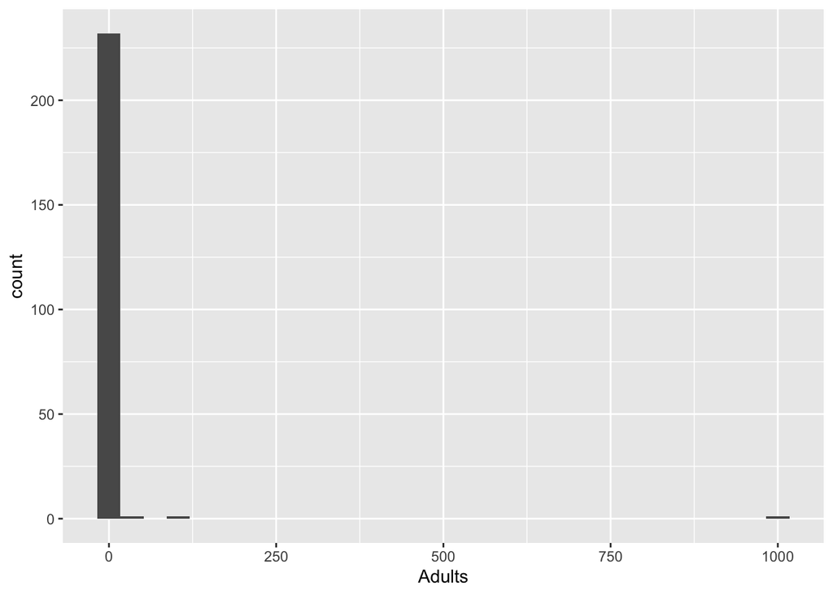

```
Adults
   0    1    2    3    5    8    9   10   15   50  100 1000 <NA>
   2  187   24    8    6    1    1    2    1    1    1    1  324
```

So little data is recorded that this is unlikely to be useful.

```
    STUDY_AREA_NAME_shrt Year           TRANSECT SPECIES_CODE EggMasses Adults VERSION_NO A16 A17  A18  A26 A14 A15 A16.1  A24
4        Alice Lake Park 2015 Fawn Lake Transect       A-ANBO        NA     10        1.3  NA  NA   10 <NA>  NA  NA    NA <NA>
432      Wells Gray Park 2018         Alice Lake       A-ANBO        NA     50        1.3  NA  NA   50 <NA>  NA  NA    NA <NA>
433      Wells Gray Park 2018         Alice Lake       A-ANBO        NA     15        1.3  NA  NA   15 <NA>  NA  NA    NA <NA>
435      Wells Gray Park 2018        Shadow Lake       A-ANBO        NA    100        1.3  NA  NA  100 <NA>  NA  NA    NA <NA>
438      Wells Gray Park 2018        Shadow Lake     AMPHIBIA        NA     10        1.3  NA  NA   10 <NA>  NA  NA    NA <NA>
443      Wells Gray Park 2018          West Lake       A-ANBO        NA   1000        1.3  NA  NA 1000 <NA>  NA  NA    NA <NA>
```

# 3 Berries

## 3.1 Years when each study area was surveyed

```
Number of records in each study area x year combination
```

```
                      Year
STUDY_AREA_NAME_shrt   2013 2014 2015 2016 2017 2018 2019 2020 2021 Sum
  Ancient Forest/Chun     0    0    0    0   20   20    0    0    0  40
  Beatton Park            0   20   20   20    0    0    0    0    0  60
  Bowser Ecological Re   20   20   20   20   20   20   20   20   20 180
  Crooked River Park     20   20   20   40    0    0    0   23    0 123
  E.C. Manning Park      20   20   20    0    0   20   20   20    0 120
  Elk Falls Provincial    0    0    0    0    0   20   20   20   20  80
  Eskers Park             0    0   20   20   20    0    0    0    0  60
  Fiordland Conservanc    0    0    0    0    0    0    0    0   20  20
  Golden Ears Park        0    0   20   20   19   20   20    0    0  99
  Goldstream Park         0    0    0    0   20   20    0    0   24  64
  John Dean Park          0    0   20   20   20   20    0    0   20 100
  Mount Robson Park       0    0   20   20    0   20   20   30   22 132
  Mount Seymour Park      0    0   20   20    0   22    0    0    0  62
  Muncho Lake Park        0    0   20   19    0   19    0   19    0  77
  Okanagan Mountain Pa    0   20    0   20    0   20    0   20    0  80
  Purcell Wilderness C    0    0    0   20   20   20   20   20   20 120
  Schoen Lake Park        0    0   20   20   20   20   18   20    0 118
  Skagit Valley Park      0    0    0   20    0   20   20    0   20  80
  Strathcona Park         0   20    0   20   20   20   20   20   20 140
  Tarahne Park            0    0    0    0    0    0    0   20    0  20
  Tatshenshini Alsek P    0    0   20    0    0    0   20    0    0  40
  Yaaguun Gandlaay Her    0   20   20   20   20   25   20   20   24 169
```

## 3.2 Sites with odd numbers of records

Notice that some sites appear to have additional records or missing records, e.g. count is not 20

```
Cases with odd Number of records in each study area x year combination
```

```
                      Year
STUDY_AREA_NAME_shrt   2016 2017 2018 2019 2020 2021
  Crooked River Park     40    0    0    0   23    0
  Golden Ears Park        0   19    0    0    0    0
  Goldstream Park         0    0    0    0    0   24
  Mount Robson Park       0    0    0    0   30   22
  Mount Seymour Park      0    0   22    0    0    0
  Muncho Lake Park       19    0   19    0   19    0
  Schoen Lake Park        0    0    0   18    0    0
  Yaaguun Gandlaay Her    0    0   25    0    0   24
```

## 3.3 Missing lat/long information

The Ecodomain of each study area was obtained by looking up the mean latitude/longitude of observations for each STUDY_AREA in the Ecoprovices provided in the *bcmaps* package. In some cases, latitude/longitude is not available for a record. This needs to be added to the record

```
Total records missing lat/long is  1364
```

```
Tabulation of where missing lat/long occurs
```

```
                      Year
STUDY_AREA_NAME_shrt   2013 2014 2015 2016 2017 2018 2019 2020 2021
  Ancient Forest/Chun     0    0    0    0   20   20    0    0    0
  Beatton Park            0   20   20    0    0    0    0    0    0
  Bowser Ecological Re   20   20   20   20   20   20   20   20   20
  Crooked River Park     20   20   20   17    0    0    0   18    0
  E.C. Manning Park      20   20   20    0    0   20   20   20    0
  Elk Falls Provincial    0    0    0    0    0    0    0    0   18
  Eskers Park             0    0   10    0    0    0    0    0    0
  Golden Ears Park        0    0   20   20   19   20   20    0    0
  Goldstream Park         0    0    0    0   20   20    0    0   20
  John Dean Park          0    0    3    5   20   20    0    0    3
  Muncho Lake Park        0    0   20   19    0   19    0   19    0
  Okanagan Mountain Pa    0   20    0   20    0   20    0   20    0
  Purcell Wilderness C    0    0    0   20   20   20   20   20   20
  Schoen Lake Park        0    0    7   20   20   20   18   17    0
  Skagit Valley Park      0    0    0   20    0   20   20    0   20
  Strathcona Park         0   20    0    0    0    0    0    0    0
  Tarahne Park            0    0    0    0    0    0    0   20    0
  Tatshenshini Alsek P    0    0   20    0    0    0   20    0    0
  Yaaguun Gandlaay Her    0   20    5   20    5   20   14   14   14
```

**How is it possible that long/lat is not known for some study area?**

## 3.4 Missing ECODOMAIN

The classification of each remaining STUDY_AREA into its EcoDomain is:

```
Site missing long/lat data so ecodomain could not be determined
```

```
   STUDY_AREA_NAME_shrt LONGITUDE_DD LATITUDE_DD
1  Ancient Forest/Chun           NaN         NaN
3  Bowser Ecological Re          NaN         NaN
5     E.C. Manning Park          NaN         NaN
9      Golden Ears Park          NaN         NaN
14     Muncho Lake Park          NaN         NaN
15 Okanagan Mountain Pa          NaN         NaN
16 Purcell Wilderness C          NaN         NaN
18   Skagit Valley Park          NaN         NaN
20         Tarahne Park          NaN         NaN
21 Tatshenshini Alsek P          NaN         NaN
```

```
                      ECODOMAIN
STUDY_AREA_NAME_shrt   CoastMtn HumConHigh North
  Beatton Park                0          0     1
  Crooked River Park          0          1     0
  Elk Falls Provincial        1          0     0
  Eskers Park                 0          1     0
  Fiordland Conservanc        1          0     0
  Goldstream Park             1          0     0
  John Dean Park              1          0     0
  Mount Robson Park           0          1     0
  Mount Seymour Park          1          0     0
  Schoen Lake Park            1          0     0
  Strathcona Park             1          0     0
  Yaaguun Gandlaay Her        1          0     0
```

## 3.5 Checking species code

### 3.5.1 Which species codes are present?

The species code should be the same across for all data values.

```
            Year
SPECIES_CODE 2013 2014 2015 2016 2017 2018 2019 2020 2021
     NULL       0   12    2    5    2    0    0    0    0
     SHEPCAN   20   40   98   98   20   20   20   53   22
     VACCALA    0    0    0    0    0    0    0    0    2
     VACCMEM    0    0    0    0    0    0    0    0    4
     VACCOVL    0    0    0   20   20   20   18   20    0
     VACCPAR    0   28   60   77   78  127   60   60  122
```

**Should this protocol include species that are not SHEPCAN?**

### 3.5.2 Records with NULL species codes

Data records with missing species codes

```
[1] TRUE TRUE TRUE TRUE TRUE TRUE TRUE TRUE
```

```
     STUDY_AREA_NAME_shrt Year SPECIES_CODE        BUSH                STEM Berry.Count Branch.Diameter..mm. Mean.Berry.Weight..gm.
66     Crooked River Park 2015         NULL      plant2      plant2-branch3        <NA>                 <NA>                   <NA>
150    Crooked River Park 2015         NULL      plant2      plant2-branch4        <NA>                 <NA>                   <NA>
513     Mount Robson Park 2016         NULL      plant1     plant1-branch26        <NA>                 <NA>                   <NA>
536     Mount Robson Park 2016         NULL      plant1     plant1-branch25        <NA>                 <NA>                   <NA>
875       Strathcona Park 2014         NULL plant2-2014 plant2-2014-branch2        <NA>                 <NA>                   <NA>
876       Strathcona Park 2014         NULL plant2-2014 plant2-2014-branch1        <NA>                 <NA>                   <NA>
877       Strathcona Park 2014         NULL plant3-2014 plant3-2014-branch2        <NA>                 <NA>                   <NA>
878       Strathcona Park 2014         NULL plant3-2014 plant3-2014-branch1        <NA>                 <NA>                   <NA>
879       Strathcona Park 2014         NULL plant4-2014 plant4-2014-branch2        <NA>                 <NA>                   <NA>
880       Strathcona Park 2014         NULL plant4-2014 plant4-2014-branch1        <NA>                 <NA>                   <NA>
881       Strathcona Park 2014         NULL plant5-2014 plant5-2014-branch2        <NA>                 <NA>                   <NA>
882       Strathcona Park 2014         NULL plant5-2014 plant5-2014-branch1        <NA>                 <NA>                   <NA>
883       Strathcona Park 2014         NULL plant6-2014 plant6-2014-branch2        <NA>                 <NA>                   <NA>
884       Strathcona Park 2014         NULL plant6-2014 plant6-2014-branch1        <NA>                 <NA>                   <NA>
885       Strathcona Park 2014         NULL plant7-2014 plant7-2014-branch1        <NA>                 <NA>                   <NA>
886       Strathcona Park 2014         NULL plant7-2014 plant7-2014-branch2        <NA>                 <NA>                   <NA>
898       Strathcona Park 2017         NULL      plant4      plant4-branch2        <NA>                 <NA>                 0.0496
945       Strathcona Park 2017         NULL      plant4      plant4-branch1        <NA>                 <NA>                 0.0496
970  Yaaguun Gandlaay Her 2016         NULL      plant5     plant5-branch2a        <NA>                 <NA>                   0.19
993  Yaaguun Gandlaay Her 2016         NULL      plant6      plant6-branch2        <NA>                 <NA>                   0.19
1089 Yaaguun Gandlaay Her 2016         NULL     plant11     plant11-branch2        <NA>                 <NA>                   0.19
```

**Why is species code NULL?**

### 3.5.3 Where do non SHEPCAN species occur?

Tabulation of where non SHEPCAN species measured

```
Where NON SHEPCAN species measured
```

```
                      Year
STUDY_AREA_NAME_shrt   2014 2015 2016 2017 2018 2019 2020 2021
  Elk Falls Provincial    0    0    0    0   20   20   20   20
  Fiordland Conservanc    0    0    0    0    0    0    0   20
  Goldstream Park         0    0    0   20   20    0    0   24
  John Dean Park          0   20   20   20   20    0    0   20
  Mount Seymour Park      0   20   20    0   22    0    0    0
  Schoen Lake Park        0    0   20   20   20   18   20    0
  Strathcona Park         8    0   20   18   20   20   20   20
  Yaaguun Gandlaay Her   20   20   17   20   25   20   20   24
```

**Is only SHEPCAN to be analyzed in this document??**

## 3.6 Berry Weight

### 3.6.1 Missing Mean berry weight.

The mean berry weight is missing for

```
      STUDY_AREA_NAME STUDY_AREA_NAME_shrt SPECIES_CODE  ECODOMAIN Year Mean.Berry.Weight..gm.
2        Beatton Park         Beatton Park      SHEPCAN      North 2015                    NaN
3        Beatton Park         Beatton Park      SHEPCAN      North 2016                    NaN
4  Crooked River Park   Crooked River Park         NULL HumConHigh 2015                    NaN
7  Crooked River Park   Crooked River Park      SHEPCAN HumConHigh 2015                    NaN
23     John Dean Park       John Dean Park      VACCPAR   CoastMtn 2015                    NaN
28  Mount Robson Park    Mount Robson Park         NULL HumConHigh 2016                    NaN
29  Mount Robson Park    Mount Robson Park      SHEPCAN HumConHigh 2015                    NaN
30  Mount Robson Park    Mount Robson Park      SHEPCAN HumConHigh 2016                    NaN
31  Mount Robson Park    Mount Robson Park      SHEPCAN HumConHigh 2018                    NaN
38   Schoen Lake Park     Schoen Lake Park      SHEPCAN   CoastMtn 2015                    NaN
40   Schoen Lake Park     Schoen Lake Park      VACCOVL   CoastMtn 2017                    NaN
44    Strathcona Park      Strathcona Park         NULL   CoastMtn 2014                    NaN
46    Strathcona Park      Strathcona Park      VACCPAR   CoastMtn 2014                    NaN
```

**Why is mean berry weight missing for so many site years?**

### 3.6.2 Odd berry weight values

A summary plot of the mean berry weight in each year for each STUDY_AREA and an the trends over time is shown in Figure 1.

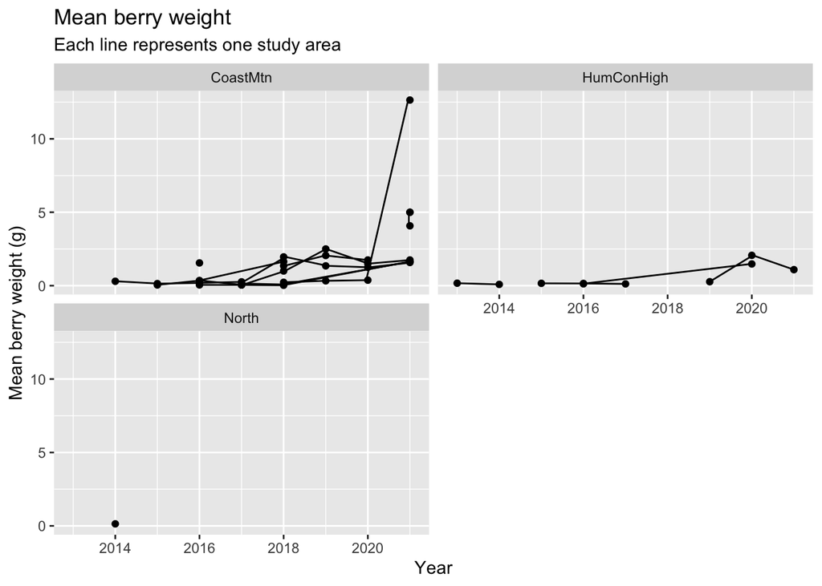

Figure 1: Summary plot of the data. The data is analyzed on the logarithmic scale.

**Strange value in Coast Mountains ECODOMAIN that needs investigation**

```
[1] TRUE TRUE TRUE TRUE
```

```
Very large mean berry weights or berry weights of 0
```

```
   STUDY_AREA_NAME_shrt Year SPECIES_CODE Mean.Berry.Weight..gm.
13 Elk Falls Provincial 2021      VACCPAR              12.642632
17 Fiordland Conservanc 2021      VACCALA               5.000000
18 Fiordland Conservanc 2021      VACCMEM               5.000000
19 Fiordland Conservanc 2021      VACCPAR               4.076923
33    Mount Robson Park 2020      SHEPCAN               2.066667
42     Schoen Lake Park 2019      VACCOVL               2.055556
50      Strathcona Park 2019      VACCPAR               2.500000
```

## 3.7 Stem Diameter.

The first few records are:

```
  STUDY_AREA_NAME_shrt ECODOMAIN Year    BUSH             STEM Branch.Diameter..mm.
1         Beatton Park     North 2016  plant2  plant2-branch35                  4.2
2         Beatton Park     North 2015  plant2  plant2-branch34                  9.5
3         Beatton Park     North 2014 plant10 plant10-branch51                  4.0
4         Beatton Park     North 2015  plant8  plant8-branch47                 15.3
5         Beatton Park     North 2014  plant7  plant7-branch44                  9.3
6         Beatton Park     North 2015  plant1  plant1-branch33                  1.5
```

### 3.7.1 Missing bush/stem values

```
[1] TRUE TRUE TRUE TRUE TRUE TRUE
```

```
    STUDY_AREA_NAME_shrt SPECIES_CODE Year BUSH             STEM Branch.Diameter..mm.
88    Crooked River Park      SHEPCAN 2020 <NA> plant11-branch19                   NA
89    Crooked River Park      SHEPCAN 2020 <NA> plant11-branch20                   NA
134   Crooked River Park      SHEPCAN 2020 <NA>  plant5-branch45                  7.0
135   Crooked River Park      SHEPCAN 2020 <NA>   plant5-branch8                  7.0
619    Mount Robson Park      SHEPCAN 2021 <NA>  plant12-branch3                 14.0
624    Mount Robson Park      SHEPCAN 2020 <NA>  plant11-branch1                 12.0
633    Mount Robson Park      SHEPCAN 2021 <NA>  plant11-branch1                 12.5
634    Mount Robson Park      SHEPCAN 2021 <NA>  plant11-branch2                 10.0
636    Mount Robson Park      SHEPCAN 2021 <NA>  plant12-branch4                 10.0
638    Mount Robson Park      SHEPCAN 2020 <NA>  plant11-branch2                  9.0
```

### 3.7.2 Missing branch diameter or value of 0

```
[1] TRUE TRUE TRUE TRUE TRUE TRUE
```

```
     STUDY_AREA_NAME_shrt SPECIES_CODE Year        BUSH                STEM Branch.Diameter..mm.
66     Crooked River Park         NULL 2015      plant2      plant2-branch3                   NA
88     Crooked River Park      SHEPCAN 2020        <NA>    plant11-branch19                   NA
89     Crooked River Park      SHEPCAN 2020        <NA>    plant11-branch20                   NA
103    Crooked River Park      SHEPCAN 2020      plant2     plant2-branch47                   NA
126    Crooked River Park      SHEPCAN 2020      plant8     plant8-branch16                   NA
133    Crooked River Park      SHEPCAN 2020     plant10    plant10-branch19                   NA
147    Crooked River Park      SHEPCAN 2020      plant7     plant7-branch13                   NA
149    Crooked River Park      SHEPCAN 2020      plant7     plant7-branch14                   NA
150    Crooked River Park         NULL 2015      plant2      plant2-branch4                   NA
152    Crooked River Park      SHEPCAN 2020      plant9     plant9-branch17                   NA
167    Crooked River Park      SHEPCAN 2016      plant5     plant5-branch10                   NA
332  Fiordland Conservanc      VACCPAR 2021     plant 8        plant8-stem1                    0
334  Fiordland Conservanc      VACCPAR 2021     plant 9        plant9-stem2                    0
477        John Dean Park      VACCPAR 2021      plant7      plant7-branch1                   NA
```

[output cut: 55 more lines]

### 3.7.3 Preliminary plot

A summary plot of the mean stem diameter in each year for each STUDY_AREA and an the trends over time is shown in Figure 2.

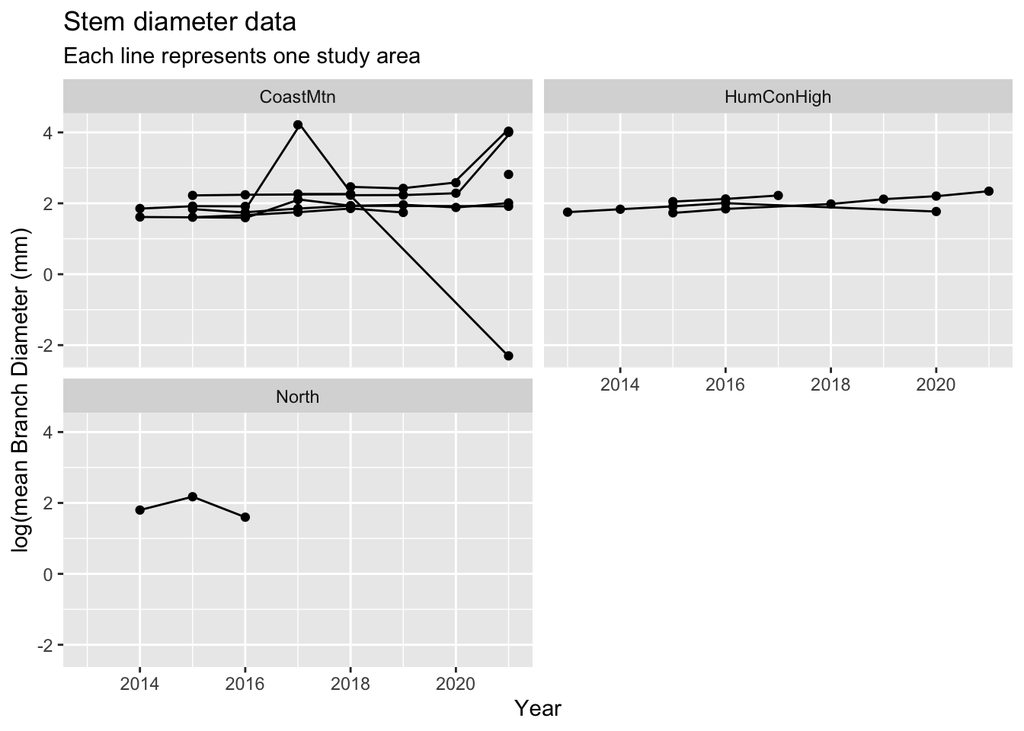

Figure 2: Summary plot of the data. The data is analyzed on the logarithmic scale.

**Need to check out the odd value for Coast Mountain stem diameter**.

```
   STUDY_AREA_NAME ECODOMAIN Year Branch.Diameter..mm.
19 Goldstream Park  CoastMtn 2021                  0.1
```

```
   STUDY_AREA_NAME_shrt SPECIES_CODE Year    BUSH             STEM Branch.Diameter..mm.
1       Goldstream Park      VACCPAR 2021  plant7   plant7-branch2                  0.1
2       Goldstream Park      VACCPAR 2021  plant8  plant8-branch2a                  0.1
3       Goldstream Park      VACCPAR 2021  plant6   plant6-branch2                  0.1
4       Goldstream Park      VACCPAR 2021  plant1   plant1-branch2                  0.1
5       Goldstream Park      VACCPAR 2021  plant5   plant5-branch1                  0.1
6       Goldstream Park      VACCPAR 2021  plant6   plant6-branch1                  0.1
7       Goldstream Park      VACCPAR 2021  plant2  plant2-branch2a                  0.1
8       Goldstream Park      VACCPAR 2021 plant10 plant10-branch1a                  0.1
9       Goldstream Park      VACCPAR 2021  plant3   plant3-branch1                  0.1
10      Goldstream Park      VACCPAR 2021  plant9   plant9-branch2                  0.1
11      Goldstream Park      VACCPAR 2021  plant9   plant9-branch1                  0.1
12      Goldstream Park      VACCPAR 2021  plant7  plant7-branch2a                  0.1
13      Goldstream Park      VACCPAR 2021  plant5   plant5-branch2                  0.1
14      Goldstream Park      VACCPAR 2021  plant8   plant8-branch2                  0.1
15      Goldstream Park      VACCPAR 2021  plant3   plant3-branch2                  0.1
16      Goldstream Park      VACCPAR 2021  plant1   plant1-branch1                  0.1
17      Goldstream Park      VACCPAR 2021  plant8   plant8-branch1                  0.1
18      Goldstream Park      VACCPAR 2021  plant2   plant2-branch1                  0.1
19      Goldstream Park      VACCPAR 2021  plant4   plant4-branch1                  0.1
20      Goldstream Park      VACCPAR 2021  plant4   plant4-branch2                  0.1
21      Goldstream Park      VACCPAR 2021  plant7   plant7-branch1                  0.1
22      Goldstream Park      VACCPAR 2021 plant10  plant10-branch1                  0.1
23      Goldstream Park      VACCPAR 2021  plant2   plant2-branch2                  0.1
24      Goldstream Park      VACCPAR 2021 plant10  plant10-branch2                  0.1
```

## 3.8 Berry Count.

The first few records are:

```
[1] FALSE FALSE FALSE FALSE FALSE FALSE
```

```
  STUDY_AREA_NAME_shrt ECODOMAIN Year    BUSH             STEM Berry.Count
1         Beatton Park     North 2016  plant2  plant2-branch35           4
2         Beatton Park     North 2015  plant2  plant2-branch34           2
3         Beatton Park     North 2014 plant10 plant10-branch51           7
4         Beatton Park     North 2015  plant8  plant8-branch47          28
5         Beatton Park     North 2014  plant7  plant7-branch44          38
6         Beatton Park     North 2015  plant1  plant1-branch33           4
```

Missing values are excluded.

### 3.8.1 Missing bush/stem values

```
    STUDY_AREA_NAME_shrt  ECODOMAIN Year BUSH             STEM Berry.Count
88    Crooked River Park HumConHigh 2020 <NA> plant11-branch19           0
89    Crooked River Park HumConHigh 2020 <NA> plant11-branch20           0
134   Crooked River Park HumConHigh 2020 <NA>  plant5-branch45          11
135   Crooked River Park HumConHigh 2020 <NA>   plant5-branch8          43
619    Mount Robson Park HumConHigh 2021 <NA>  plant12-branch3          31
624    Mount Robson Park HumConHigh 2020 <NA>  plant11-branch1          74
633    Mount Robson Park HumConHigh 2021 <NA>  plant11-branch1          44
634    Mount Robson Park HumConHigh 2021 <NA>  plant11-branch2          32
636    Mount Robson Park HumConHigh 2021 <NA>  plant12-branch4          18
638    Mount Robson Park HumConHigh 2020 <NA>  plant11-branch2          66
```

### 3.8.2 Missing berry count

```
[1] TRUE TRUE TRUE TRUE TRUE TRUE
```

```
     STUDY_AREA_NAME_shrt SPECIES_CODE Year        BUSH                STEM Berry.Count
66     Crooked River Park         NULL 2015      plant2      plant2-branch3          NA
150    Crooked River Park         NULL 2015      plant2      plant2-branch4          NA
167    Crooked River Park      SHEPCAN 2016      plant5     plant5-branch10          NA
332  Fiordland Conservanc      VACCPAR 2021     plant 8        plant8-stem1          NA
399       Goldstream Park      VACCPAR 2021      plant2      plant2-branch2          NA
513     Mount Robson Park         NULL 2016      plant1     plant1-branch26          NA
520     Mount Robson Park      SHEPCAN 2020     plant10  plant10-branch3-44          NA
521     Mount Robson Park      SHEPCAN 2020     plant10  plant10-branch1-43          NA
522     Mount Robson Park      SHEPCAN 2020     plant10  plant10-branch2-44          NA
535     Mount Robson Park      SHEPCAN 2020      plant3   plant3-branch1-29          NA
536     Mount Robson Park         NULL 2016      plant1     plant1-branch25          NA
554     Mount Robson Park      SHEPCAN 2020      plant4   plant4-branch2-32          NA
557     Mount Robson Park      SHEPCAN 2020      plant5   plant5-branch2-34          NA
560     Mount Robson Park      SHEPCAN 2020      plant5   plant5-branch1-33          NA
```

[output cut: 30 more lines]

### 3.8.3 Very large berry count values

Here is a histogram of the berry counts. Some values appear to be very large!

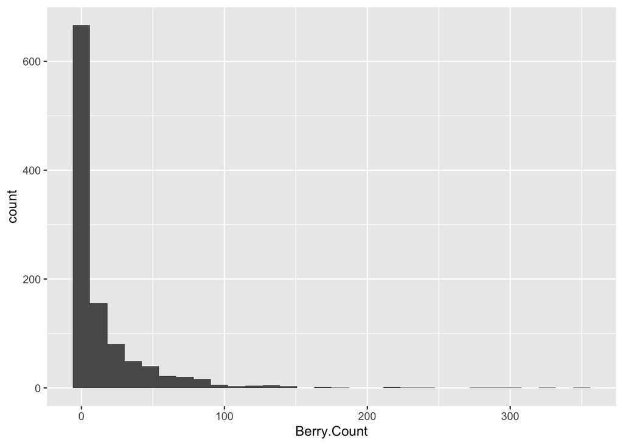

```
     STUDY_AREA_NAME_shrt SPECIES_CODE Year    BUSH            STEM Berry.Count
98     Crooked River Park      SHEPCAN 2016  plant9 plant9-branch18         116
146    Crooked River Park      SHEPCAN 2016  plant7 plant7-branch13         141
155    Crooked River Park      SHEPCAN 2016  plant3  plant3-branch5         176
201  Elk Falls Provincial      VACCPAR 2019  plant4  plant4-branch2         131
212  Elk Falls Provincial      VACCPAR 2020  plant7  plant7-branch1         101
213  Elk Falls Provincial      VACCPAR 2019  plant7  plant7-branch1         125
227  Elk Falls Provincial      VACCPAR 2018  plant9  plant9-branch1         119
228  Elk Falls Provincial      VACCPAR 2019  plant9  plant9-branch1         133
232  Elk Falls Provincial      VACCPAR 2019  plant1  plant1-branch1         296
233  Elk Falls Provincial      VACCPAR 2020  plant1  plant1-branch1         218
238  Elk Falls Provincial      VACCPAR 2018  plant1  plant1-branch1         292
285           Eskers Park      SHEPCAN 2016  plant7 plant7-branch14         350
288           Eskers Park      SHEPCAN 2016  plant3  plant3-branch6         150
299           Eskers Park      SHEPCAN 2016  plant5 plant5-branch10         103
316           Eskers Park      SHEPCAN 2016  plant8 plant8-branch15         222
318           Eskers Park      SHEPCAN 2016  plant8 plant8-branch16         236
646    Mount Seymour Park      VACCPAR 2018  plant3 plant3-branch1a         138
668    Mount Seymour Park      VACCPAR 2018  plant7  plant7-branch1         325
677    Mount Seymour Park      VACCPAR 2018  plant8  plant8-branch2         164
678    Mount Seymour Park      VACCPAR 2018  plant9  plant9-branch1         281
684    Mount Seymour Park      VACCPAR 2018  plant4  plant4-branch2         104
693    Mount Seymour Park      VACCPAR 2016  plant8  plant8-branch2         103
699    Mount Seymour Park      VACCPAR 2016  plant2  plant2-branch1         138
972  Yaaguun Gandlaay Her      VACCPAR 2018  plant5 plant5-branch1a         125
983  Yaaguun Gandlaay Her      VACCPAR 2018 plant12 plant12-branch2         146
988  Yaaguun Gandlaay Her      VACCPAR 2021 plant12 plant12-branch1         175
1086 Yaaguun Gandlaay Her      VACCPAR 2018  plant9  plant9-branch1         132
1112 Yaaguun Gandlaay Her      VACCPAR 2021  plant9  plant9-branch1         230
```

### 3.8.4 Preliminary plot

A summary plot of the mean berry count in each year for each STUDY_AREA and an the trends over time is shown in Figure 3.

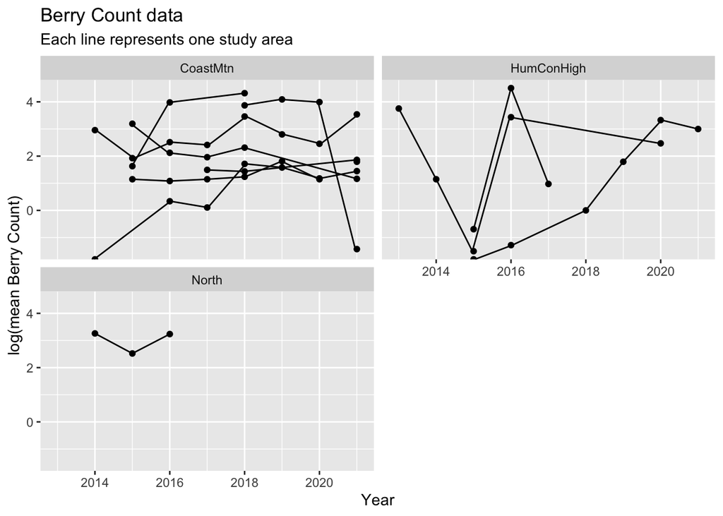

Figure 3: Summary plot of the data. The data is analyzed on the logarithmic scale.

Some mean berry counts are very small:

```
             STUDY_AREA_NAME  ECODOMAIN Year mean.Berry.Count
6         Crooked River Park HumConHigh 2015        0.2222222
12 Elk Falls Provincial Park   CoastMtn 2021        0.2400000
13               Eskers Park HumConHigh 2015        0.5000000
25         Mount Robson Park HumConHigh 2015        0.0000000
26         Mount Robson Park HumConHigh 2016        0.2777778
40           Strathcona Park   CoastMtn 2014        0.0000000
```

# 4 Squirrels

## 4.1 Year when each study area was surveyed

```
Number of records in each study area x year combination
```

```
                      Year
STUDY_AREA_NAME_shrt   2013 2014 2015 2016 2017 2018 2019 2020 2021 Sum
  Beatton Provincial P    0    0   24   34    0    0    0    0    0  58
  Bowser Ecological Re    0    0    7   10    3    0    0   12    6  38
  Call Lake Park          0    0    0   72   39   25   13   33    0 182
  Crooked River Park      0    0    5   10    0    0    0    0    0  15
  E.C. Manning Park       0    0   16    6    0   20   69   16    0 127
  Eskers Park             0    0    2   26    0    0    0    0    0  28
  Goldstream Park         0    0    0    0    5   18   15    0    8  46
  John Dean Park         11    1    6   18   15   17   17   15    0 100
  Kinaskin Lake Park      0    0    0    0  101    0   46   47   31 225
  Lakelse Lake Park       0    0   34    0   41   16   12    6   41 150
  Liard River Corridor    5    0    0    0    0    0    0    0    0   5
  Mount Robson Park       0    0    0    0    0   16   26   18   19  79
  Mount Seymour Park      0    3    0    0    0   10    0    0   16  29
  Muncho Lake Park        0    0   15   42   27   31    0    7   23 145
  Okanagan Mountain Pa    0   46    0   26    0   23    9   16    0 120
  Purcell Wilderness C   67   18   29   50   86   24   23   18   17 332
  Schoen Lake Provinci    4    4    4    3    4    3    2    2    0  26
  Skagit Valley Park      0    0    0   58   52   16   34    0   16 176
  Strathcona Park         0   10    0   11   14    0    5   14   10  64
  Tarahne Park            0    0    0    0    0    0   29   46   25 100
  West Arm Park           0    0   27   54   34    0    0    0    0 115
  Yaaguun Gandlaay Con    0    0    7   20    0    0   25   46   27 125
```

## 4.2 Sites with odd numbers of records

Notice that some sites appear to have only a very small number of records (< 10)?

```
Cases with odd Number of records in each study area x year combination
```

```
                      Year
STUDY_AREA_NAME_shrt   2013 2014 2015 2016 2017 2018 2019 2020 2021
  Bowser Ecological Re    0    0    7    0    3    0    0    0    6
  Crooked River Park      0    0    5    0    0    0    0    0    0
  E.C. Manning Park       0    0    0    6    0    0    0    0    0
  Eskers Park             0    0    2    0    0    0    0    0    0
  Goldstream Park         0    0    0    0    5    0    0    0    8
  John Dean Park          0    1    6    0    0    0    0    0    0
  Lakelse Lake Park       0    0    0    0    0    0    0    6    0
  Liard River Corridor    5    0    0    0    0    0    0    0    0
  Mount Seymour Park      0    3    0    0    0    0    0    0    0
  Muncho Lake Park        0    0    0    0    0    0    0    7    0
  Okanagan Mountain Pa    0    0    0    0    0    0    9    0    0
  Schoen Lake Provinci    4    4    4    3    4    3    2    2    0
  Strathcona Park         0    0    0    0    0    0    5    0    0
  Yaaguun Gandlaay Con    0    0    7    0    0    0    0    0    0
```

## 4.3 Missing lat/long information

The Ecodomain of each study area was obtained by looking up the mean latitude/longitude of observations for each STUDY_AREA in the Ecoprovices provided in the *bcmaps* package. In some cases, latitude/longitude is not available for a record. This needs to be added to the record

```
Total records missing lat/long is  0
```

```
Tabulation of where missing lat/long occurs
```

```
< table of extent 0 x 0 >
```

**How is it possible that long/lat is not known for some study area?**

## 4.4 Missing ECODOMAIN

The classification of each remaining STUDY_AREA into its EcoDomain is:

```
Site missing long/lat data so ecodomain could not be determined
```

```
[1] STUDY_AREA_NAME_shrt LONGITUDE_DD         LATITUDE_DD
<0 rows> (or 0-length row.names)
```

```
                      ECODOMAIN
STUDY_AREA_NAME_shrt   CoastMtn HumConHigh North SemiAridHigh
  Beatton Provincial P        0          0     1            0
  Bowser Ecological Re        1          0     0            0
  Call Lake Park              0          1     0            0
  Crooked River Park          0          1     0            0
  E.C. Manning Park           0          0     0            1
  Eskers Park                 0          1     0            0
  Goldstream Park             1          0     0            0
  John Dean Park              1          0     0            0
  Kinaskin Lake Park          0          0     1            0
  Lakelse Lake Park           1          0     0            0
  Liard River Corridor        0          0     1            0
  Mount Robson Park           0          1     0            0
  Mount Seymour Park          1          0     0            0
  Muncho Lake Park            0          0     1            0
  Okanagan Mountain Pa        0          0     0            1
  Purcell Wilderness C        0          1     0            0
  Schoen Lake Provinci        1          0     0            0
  Skagit Valley Park          0          0     0            1
  Strathcona Park             1          0     0            0
  Tarahne Park                0          0     1            0
  West Arm Park               0          1     0            0
  Yaaguun Gandlaay Con        1          0     0            0
```

## 4.5 Checking species code

### 4.5.1 Which species codes are present?

The species code should be the same across for all data values.

```
            Year
SPECIES_CODE 2013 2014 2015 2016 2017 2018 2019 2020 2021
      M-LYCA    0    0    0    0    0    1    0    0    0
      M-SCCA    0    0    0    0    0    1    0    0    0
      M-TADO    0    0    0    0    0    0    0    1    2
      M-TAHU   75   71  155  397  391  138  282  251  186
      NULL     12   11   21   43   30   79   43   44   51
```

**Should this protocol include species that are not TAHU?

### 4.5.2 Records with NULL species codes

Data records with missing species codes

```
[1] TRUE TRUE TRUE TRUE TRUE
```

```
     STUDY_AREA_NAME_shrt Year SPECIES_CODE TRANSECT COUNT
39   Beatton Provincial P 2016         NULL   4-2016     0
43   Beatton Provincial P 2016         NULL   5-2016     0
47   Beatton Provincial P 2016         NULL   3-2016     0
48   Beatton Provincial P 2016         NULL   3-2016     0
49   Beatton Provincial P 2016         NULL   3-2016     0
60   Bowser Ecological Re 2017         NULL       T1     0
61   Bowser Ecological Re 2020         NULL       T1     0
62   Bowser Ecological Re 2016         NULL       T1     0
65   Bowser Ecological Re 2020         NULL       T1     0
67   Bowser Ecological Re 2016         NULL       T2     0
69   Bowser Ecological Re 2016         NULL       T2     0
71   Bowser Ecological Re 2017         NULL       T2     0
73   Bowser Ecological Re 2020         NULL       T2     0
74   Bowser Ecological Re 2021         NULL       T1     0
```

[output cut: 320 more lines]

**Why is species code NULL?**

## 4.6 Transect codes

The transect codes are not coded consistently across the study areas. In particular, I’m assuming that, for example, T1 measured over multiple years is the same transect. So is “1-2015” and “T1-2015” the same transect? Is “T1-2015” and “T1-2016” the same transect measured in different years?

```
    STUDY_AREA_NAME_shrt TRANSECT Freq
1   Beatton Provincial P        1    0
23  Beatton Provincial P   1-2015    0
45  Beatton Provincial P   1-2016   12
67  Beatton Provincial P        2    0
89  Beatton Provincial P   2-2015    0
111 Beatton Provincial P   2-2016    3
133 Beatton Provincial P 2019 - 1    0
155 Beatton Provincial P 2019 - 2    0
177 Beatton Provincial P 2019 - 3    0
199 Beatton Provincial P        3    0
221 Beatton Provincial P   3-2015    0
243 Beatton Provincial P   3-2016    3
265 Beatton Provincial P        4    0
287 Beatton Provincial P   4-2015    0
```

[output cut: 602 more lines]

## 4.7 Calls.

### 4.7.1 Summarize to transect level

The data is first summarized to the transect-year level by finding the mean number of calls on a transect over multiple visits for each individual transect. This reduces the data to one measurement per transect per STUDY_AREA/year.

The first few records are:

```
  STUDY_AREA_NAME_shrt ECODOMAIN Year TRANSECT mean.calls
1 Beatton Provincial P     North 2015  T1-2015          1
2 Beatton Provincial P     North 2015  T2-2015          1
3 Beatton Provincial P     North 2015  T3-2015          1
4 Beatton Provincial P     North 2015  T4-2015          1
5 Beatton Provincial P     North 2015  T5-2015          1
6 Beatton Provincial P     North 2016   1-2016          1
```

It is implicitly assumed that all transects are run on all days within a STUDY_AREA so every transect has the same number of days of measurement. If transects are changed over time, that is not a problem, but transects should not be introduced or removed part way through a year.

### 4.7.2 Preliminary plot

A summary plot of the mean number of calls in each year for each STUDY_AREA and an the trends over time is shown in Figure 4.

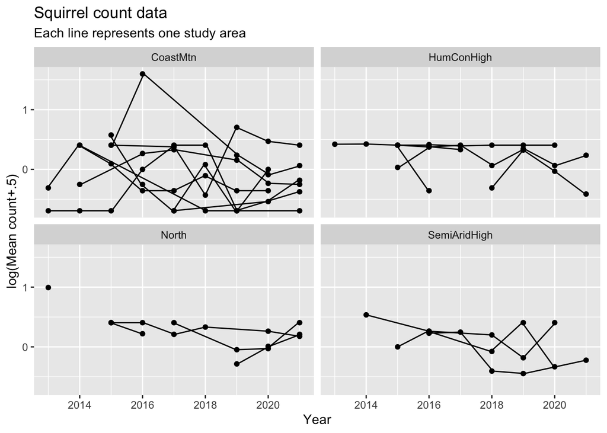

Figure 4: Summary plot of the data. The data is analyzed on the logarithmic scale.

# 5 Waterfowl

## 5.1 Years when each study area was surveyed

```
Number of records in each study area x year combination
```

```
                      Year
STUDY_AREA_NAME_shrt   2007 2013 2014 2015 2016 2017 2018 2019 2020 2021 Sum
  Alice Lake Provincia    0    0    5    2    2    0    2    0    2    0  13
  Big Bar Lake Provinc    0    0    0    1    0    0    2    5    2    0  10
  Bowron Lake Provinci    0    0    0    1    0    0    0    0    0    0   1
  Brandywine Falls Pro    0    0    0    7    3    0    0    0    4    0  14
  Burges James Gadsden    0    0    0    2    2    0   15   29   54    0 102
  Call Lake Provincial    0    0    0   12    7    0    3    6    0    0  28
  Champion Lakes Provi    0    0    0    4    4    3    3    8    2    4  28
  Hai Lake Mount Herma    0    0    0   13   15   12   12   16   12    6  86
  Lac du Bois Provinci    0    2    1    1    0    0    0    0    3    0   7
  Mahoney Lake Ecologi    0    0    0   14   27   23   36   39   47    0 186
  Misty Lake Ecologica    3    0    0    5    6    7    4   10    0    0  35
  Naikoon Provincial P    0    0    0    2    0    1    0    0    0    0   3
  Nazko Lake Provincia    0    3    0    4    0    0    9    1    0    0  17
  Wells Gray Provincia    0    0    0    0    0    0    6    3    1    0  10
  White Lake Provincia    0    0    0    0    0    0    5    0    0    3   8
  Yellow Point Bog Eco    0   27   44  153   55  127    0   93    2  110 611
```

## 5.2 Sites with odd numbers of records

```
Cases with odd Number of records in each study area x year combination
```

```
                      Year
STUDY_AREA_NAME_shrt   2015 2016 2017 2019 2020 2021
  Burges James Gadsden    0    0    0    0   54    0
  Yellow Point Bog Eco  153   55  127   93    0  110
```

## 5.3 Missing lat/long information

The Ecodomain of each study area was obtained by looking up the mean latitude/longitude of observations for each STUDY_AREA in the Ecoprovices provided in the *bcmaps* package. In some cases, latitude/longitude is not available for a record. This needs to be added to the record

```
Total records missing lat/long is  6
```

```
Tabulation of where missing lat/long occurs
```

```
                      Year
STUDY_AREA_NAME_shrt   2016 2020
  Mahoney Lake Ecologi    2    4
```

**How is it possible that long/lat is not known for some study area?**

## 5.4 Missing ECODOMAIN

The classification of each remaining STUDY_AREA into its EcoDomain is:

```
Site missing long/lat data so ecodomain could not be determined
```

```
[1] STUDY_AREA_NAME_shrt LONGITUDE_DD         LATITUDE_DD
<0 rows> (or 0-length row.names)
```

```
                      ECODOMAIN
STUDY_AREA_NAME_shrt   CoastMtn HumConHigh SemiAridHigh
  Alice Lake Provincia        1          0            0
  Big Bar Lake Provinc        0          1            0
  Bowron Lake Provinci        0          1            0
  Brandywine Falls Pro        1          0            0
  Burges James Gadsden        0          1            0
  Call Lake Provincial        0          1            0
  Champion Lakes Provi        0          1            0
  Hai Lake Mount Herma        1          0            0
  Lac du Bois Provinci        0          0            1
  Mahoney Lake Ecologi        0          0            1
  Misty Lake Ecologica        1          0            0
  Naikoon Provincial P        1          0            0
  Nazko Lake Provincia        0          1            0
  Wells Gray Provincia        0          2            0
  White Lake Provincia        0          1            0
  Yellow Point Bog Eco        1          0            0
```

## 5.5 Checking species code

### 5.5.1 Which species codes are present?

The species code should be the same across for all data values.

```
               Year
SPECIES_CODE    2007 2013 2014 2015 2016 2017 2018 2019 2020 2021
  ANATIDAE         0    3    1    0    0    0    1    5    1    3
  ANSERIFORMES     0    0    0    6    5    6    2    0    1    0
  AVES             0    0    0    0    0    0    0    0    0    5
  AYTHYA           1    0    0    1    3    0    0    1    2    0
  B-ALFL           0    0    0    0    0    0    0    1    1    0
  B-AMCO           0    0    0    0    0    4    9    9   13    1
  B-AMRO           0    0    0    0    0    0    1    2    4    0
  B-AWPE           0    0    0    0    0    0    1    0    0    0
  B-BAEA           0    0    0    0    0    0    2    2    0    0
  B-BAGO           0    1    0    1    5    2    4    2    0    0
  B-BCCH           0    0    0    0    0    0    0    1    1    0
  B-BEKI           0    0    0    1    1    0    1    1    0    0
  B-BUFF           0    0   14   18    7    2   11    8    1    5
  B-BWTE           0    0    0    0    0    3    0    0    0    1
  B-CAGO           0    3    0   25    6    7    6    7    5    0
  B-CEWA           0    0    0    0    0    0    0    0    5    0
  B-CITE           0    0    0    0    0    1    0    0    0    0
  B-COGO           0    0    0    1    2    0    2    4    4    0
  B-COLO           0    0    0    1    0    0    3    4    3    1
  B-COME           0    0    3    7    2    1    1    4    1    5
  B-CORA           0    0    0    0    0    0    0    2    1    0
  B-EAGR           0    0    0    0    0    5    0    0    0    0
  B-EAKI           0    0    0    0    0    0    0    4    4    0
  B-GBHE           0    0    2    2    1    0    0    2    0    1
  B-GRSC           0    0    1    0    2    1    0    0    0    0
  B-GWTE           0    0    0    2    2    2    0    0    0    1
  B-HOME           0   12   14   30   17   24    1   17    0   29
  B-KILL           0    0    0    3    1    0    0    5    1    0
  B-LESC           0    2    0   20    3   12    1    2    0    2
  B-MALL           0    5    3   30   14   25   13   18   10   13
  B-NOPI           0    0    0    0    0    1    0    2    0    0
  B-OCWA           0    0    0    0    0    0    0    1    0    0
  B-OSFL           0    0    0    0    0    0    0    1    2    0
  B-OSPR           0    0    0    0    0    0    1    0    3    0
  B-PBGR           0    0    0    1    2   12    7    8   10    4
  B-PIGR           0    0    0    0    0    0    0    1    0    0
  B-RBME           0    0    0    0    0    0    0    1    0    0
  B-RNDU           0    0    2   14    5   16    1   17    3   18
  B-RNGR           0    0    0    1    7    0    0    0    0    0
  B-RUDU           0    0    0    0    1    6    7    6    5    0
  B-SACR           0    1    0    1    0    0    1    0    0    0
  B-SPSA           0    0    0    2    8    0    1    4    6    0
  B-TRSW           0    0    0    0    0    0    0    9   25    0
  B-TRUS           0    0    1    1    0    3    0    0    0    3
  B-TUVU           0    0    0    0    0    0    0    0    2    0
  B-VATH           0    0    0    0    0    0    0    1    1    0
  B-WISN           0    0    0    0    1    0    1    0    0    0
  B-WIWA           0    0    0    0    0    0    0    1    0    0
  B-WIWR           0    0    0    0    0    0    0    2    0    0
  B-WODU           0    0    0    6    2    1    0    2    1    0
  B-YEWA           0    0    0    0    0    0    0    1    6    0
  BOMBYCILLIDAE    0    0    0    0    0    0    1    0    0    0
  BUCEPHALA        0    0    1    1    0    0    0    1    0    0
  CHARADRIIDAE     0    0    0    0    0    0    1    0    0    0
  MERGUS           0    0    0    0    0    0    0    2    0    0
  NULL             2    5    8   46   24   39   16   48    7   31
  PASSERIFORMES    0    0    0    0    0    0    1    0    0    0
  PODICIPEDIDAE    0    0    0    0    0    0    0    1    0    0
```

**Should this protocol record species at Family level?

### 5.5.2 Records with NULL species codes

Data records with missing species codes

```
[1] TRUE TRUE TRUE TRUE TRUE
```

```
     STUDY_AREA_NAME_shrt Year SPECIES_CODE      SAMPLE_LABEL COUNT
1    Alice Lake Provincia 2018         NULL            Site 1     0
2    Alice Lake Provincia 2015         NULL            Site 1     0
11   Alice Lake Provincia 2015         NULL            Site 2     0
12   Alice Lake Provincia 2018         NULL            Site 2     0
13   Alice Lake Provincia 2016         NULL            Site 2     0
17   Big Bar Lake Provinc 2015         NULL        Otter Lake     0
149  Call Lake Provincial 2018         NULL         Station 1     0
153  Call Lake Provincial 2016         NULL         Station 2     0
182  Champion Lakes Provi 2016         NULL          2nd Lake     0
190  Champion Lakes Provi 2018         NULL          2nd Lake     0
197  Hai Lake Mount Herma 2018         NULL                 1     0
198  Hai Lake Mount Herma 2020         NULL                 1     0
199  Hai Lake Mount Herma 2019         NULL                 1     0
201  Hai Lake Mount Herma 2017         NULL                 1     0
```

[output cut: 212 more lines]

**Why is species code NULL?**

## 5.6 SAMPLE labels

SAMPLE LABELS need some editing. For example for Alice Lake you have “Site 1”, “Site 2” and “Site 1 + Site 2”. These cannot be mixed across years.

```
    STUDY_AREA_NAME_shrt                    SAMPLE_LABEL Freq
1   Alice Lake Provincia                               1    0
17  Alice Lake Provincia                               2    0
33  Alice Lake Provincia                        2nd Lake    0
49  Alice Lake Provincia                     Boat Launch    0
65  Alice Lake Provincia Cattleguard - north end of lake    0
81  Alice Lake Provincia                    East of dyke    0
97  Alice Lake Provincia                     Interp sign    0
113 Alice Lake Provincia                             ML2    0
129 Alice Lake Provincia                             ML3    0
145 Alice Lake Provincia                      Naikoon HQ    0
161 Alice Lake Provincia                          NE pin    0
177 Alice Lake Provincia                          NW pin    0
193 Alice Lake Provincia                     Obs Pt East    0
209 Alice Lake Provincia                     Obs Pt West    0
```

[output cut: 450 more lines]

Is it sensible to have multiple SAMPLE_LABELS for a study area, such as Alice Lake?

## 5.7 Maximum counts

The data is first summarized to the date level by summing the count over the different species for each date-sample station combination. This reduces the data to one measurement per date per site/year.

The summarized data are

```
    STUDY_AREA_NAME_shrt    ECODOMAIN Year       Date                    SAMPLE_LABEL total.count                                                    SA.SAMPLE_LABEL
1   Alice Lake Provincia     CoastMtn 2014 2014-04-09                 Site 1 + Site 2           9                      Alice Lake Provincial Park....Site 1 + Site 2
2   Alice Lake Provincia     CoastMtn 2014 2014-04-11                 Site 1 + Site 2           7                      Alice Lake Provincial Park....Site 1 + Site 2
3   Alice Lake Provincia     CoastMtn 2015 2015-04-10                          Site 1           0                               Alice Lake Provincial Park....Site 1
4   Alice Lake Provincia     CoastMtn 2015 2015-04-10                          Site 2           0                               Alice Lake Provincial Park....Site 2
5   Alice Lake Provincia     CoastMtn 2016 2016-04-19                          Site 1           2                               Alice Lake Provincial Park....Site 1
6   Alice Lake Provincia     CoastMtn 2016 2016-04-19                          Site 2           0                               Alice Lake Provincial Park....Site 2
7   Alice Lake Provincia     CoastMtn 2018 2018-05-02                          Site 1           0                               Alice Lake Provincial Park....Site 1
8   Alice Lake Provincia     CoastMtn 2018 2018-05-02                          Site 2           0                               Alice Lake Provincial Park....Site 2
9   Alice Lake Provincia     CoastMtn 2020 2020-04-21                          Site 1           2                               Alice Lake Provincial Park....Site 1
10  Big Bar Lake Provinc   HumConHigh 2015 2015-06-11                      Otter Lake           0                         Big Bar Lake Provincial Park....Otter Lake
11  Big Bar Lake Provinc   HumConHigh 2018 2018-06-19                      Otter Lake           2                         Big Bar Lake Provincial Park....Otter Lake
12  Big Bar Lake Provinc   HumConHigh 2019 2019-07-19                      Otter Lake          12                         Big Bar Lake Provincial Park....Otter Lake
13  Big Bar Lake Provinc   HumConHigh 2020 2020-06-18                      Otter Lake           4                         Big Bar Lake Provincial Park....Otter Lake
14  Bowron Lake Provinci   HumConHigh 2015 2015-06-17                             OP1           1                                 Bowron Lake Provincial Park....OP1
```

[output cut: 612 more lines]

Notice that, for example, Alice Lake, the SAMPLE_LABELS are msitures of different sites; Brandywine Falls only has Station 1 in 2016, etc.

### 5.7.1 Preliminary plot

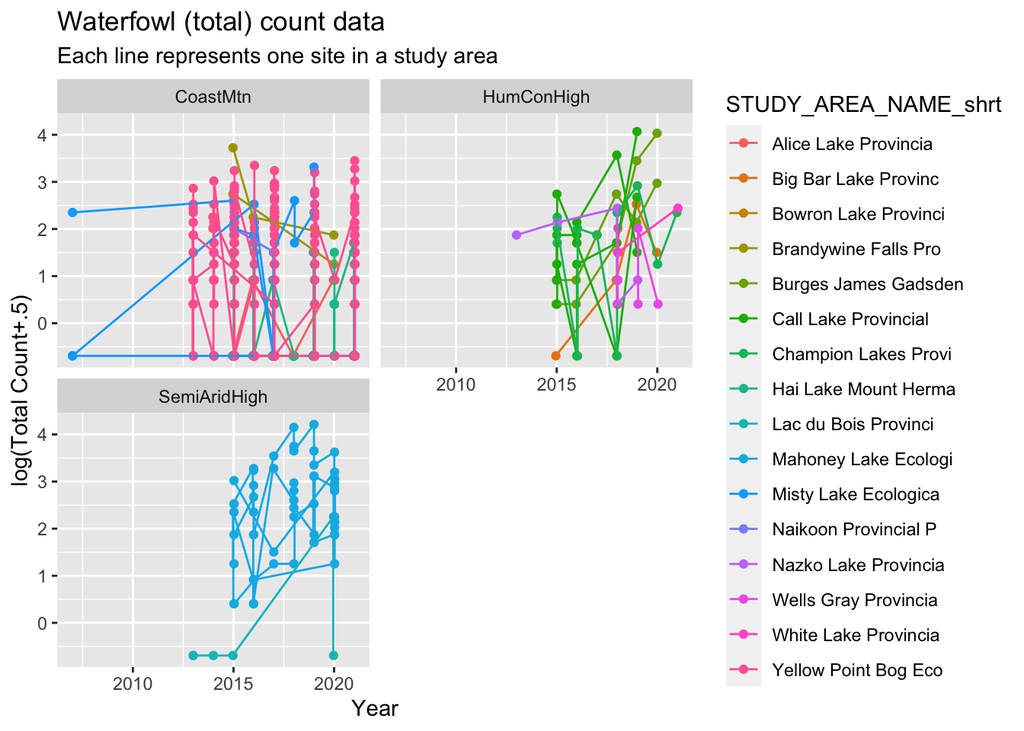

Figure 5: Summary plot of the data. The data is analyzed on the logarithmic scale.

Each line represents a particular station within a STUDY_AREA.

### 5.7.2 Obtain maximum count in N/D/J/F

Next the maximum count in each month in each station is found. The maximum counts are:

```
    STUDY_AREA_NAME_shrt    ECODOMAIN                    SAMPLE_LABEL Year Month max.count
1   Alice Lake Provincia     CoastMtn                          Site 1 2015     4         0
2   Alice Lake Provincia     CoastMtn                          Site 1 2016     4         2
3   Alice Lake Provincia     CoastMtn                          Site 1 2018     5         0
4   Alice Lake Provincia     CoastMtn                          Site 1 2020     4         2
5   Alice Lake Provincia     CoastMtn                 Site 1 + Site 2 2014     4         9
6   Alice Lake Provincia     CoastMtn                          Site 2 2015     4         0
7   Alice Lake Provincia     CoastMtn                          Site 2 2016     4         0
8   Alice Lake Provincia     CoastMtn                          Site 2 2018     5         0
9   Big Bar Lake Provinc   HumConHigh                      Otter Lake 2015     6         0
10  Big Bar Lake Provinc   HumConHigh                      Otter Lake 2018     6         2
11  Big Bar Lake Provinc   HumConHigh                      Otter Lake 2019     7        12
12  Big Bar Lake Provinc   HumConHigh                      Otter Lake 2020     6         4
13  Bowron Lake Provinci   HumConHigh                             OP1 2015     6         1
14  Brandywine Falls Pro     CoastMtn                       Station 1 2015     5        41
```

[output cut: 286 more lines]

When the maximum counts are restricted to November, December, January, and February, the data are now:

```
    STUDY_AREA_NAME_shrt ECODOMAIN SAMPLE_LABEL Year Month max.count
165 Misty Lake Ecologica  CoastMtn  Boat Launch 2007    12        10
168 Misty Lake Ecologica  CoastMtn  Boat Launch 2015    11         7
173 Misty Lake Ecologica  CoastMtn  Boat Launch 2019     1        10
175 Misty Lake Ecologica  CoastMtn          ML2 2007    12         0
178 Misty Lake Ecologica  CoastMtn          ML3 2007    12         0
198 Yellow Point Bog Eco  CoastMtn  Obs Pt East 2013    11         6
199 Yellow Point Bog Eco  CoastMtn  Obs Pt East 2014     1        12
200 Yellow Point Bog Eco  CoastMtn  Obs Pt East 2014     2         0
201 Yellow Point Bog Eco  CoastMtn  Obs Pt East 2014    11         2
202 Yellow Point Bog Eco  CoastMtn  Obs Pt East 2014    12         9
203 Yellow Point Bog Eco  CoastMtn  Obs Pt East 2015     1         6
204 Yellow Point Bog Eco  CoastMtn  Obs Pt East 2015     2         6
209 Yellow Point Bog Eco  CoastMtn  Obs Pt East 2015    11         5
210 Yellow Point Bog Eco  CoastMtn  Obs Pt East 2015    12        17
```

[output cut: 33 more lines]

Many STUDY_AREA_NAMEs were NOT measured in N/D/J/F, so the remainining data are:

```
                      Year
STUDY_AREA_NAME_shrt   2007 2013 2014 2015 2016 2017 2019 2021
  Misty Lake Ecologica    3    0    0    1    0    0    1    0
  Yellow Point Bog Eco    0    3    8    6    3    6    8    8
```

```
                      ECODOMAIN
STUDY_AREA_NAME_shrt   CoastMtn
  Misty Lake Ecologica        5
  Yellow Point Bog Eco       42
```

**Does this seem right that most study areas have NO overwintering waterfowl?** **Does this seem right that we now only have 1 ECODOMAIN**. No analysis is possible to compare trends across ECODOMAINS.

# 6 Vegetation (Alpine and Grassland)

## 6.1 Years when each study area was surveyed

```
Number of records in each study area x year combination
```

```
                      Year
STUDY_AREA_NAME_shrt   2013 2014 2015 2016 2017 2018 2019 2020 2021  Sum
  Babine Mountains Par    0    0    0    0  362    0    0    0    0  362
  Big Bar Provincial P    0    0    0    0    0    0  193    0    0  193
  Big White Mountain E    0    0    0    0  286    0    0    0    0  286
  Butler Ridge Provinc    0    0    0    0    0    0  200    0    0  200
  Callaghan Lake Provi    0    0    0    0    0    0   90    0    0   90
  Cathedral Provincial    0    0  293    0    0    0  220    0    0  513
  Clayton Falls Conser    0    0    0    0    0  191    0    0    0  191
  Columbia Lake Provin    0    0    0    0  380    0    0    0  521  901
  Duu Guusd Heritage S    0    0    0  109    0    0    0    0    0  109
  Garibaldi Provincial  266   87    0    0    0  202    0    0    0  555
  Golden Ears Provinci    0    0    0    0    0    0   84    0    0   84
  Haley Lake Ecologica    0    0    0    0    0   72    0    0    0   72
  Junction Sheep Range    0    0    0    0    0  405    0    0    0  405
  Kalamalka Lake Provi    0    0    0  185    0    0    0    0    0  185
  Kikomun Creek Provin    0    0  261    0    0    0  270    0    0  531
  Monarch Mountain/A X    0    0    0    0    0    0  135    0    0  135
  Mount Assiniboine Pr    0    0    0    0    0  417    0    0    0  417
  Mount Maxwell Ecolog    0    0    0    0    0    0  191    0    0  191
  Mount Robson Provinc    0    0  364    0    0    0    0    0  652 1016
  Mount Tzuhalem Ecolo  136    0  173    0    0    0    0  141    0  450
  Nadina Mountain Prov    0  144    0    0    0  139    0    0    0  283
  Seven Sisters Provin    0    0  315    0    0    0  248    0    0  563
  Spatsizi Plateau Wil    0    0    0    0  289    0    0    0    0  289
  Squitty Bay Provinci    0    0    0    0  321    0   37    0    0  358
  Stagleap Provincial     0   48    0    0    0    0    0    0    0   48
  Stone Mountain Provi    0    0    0  284    0    0    0    0  220  504
  Strathcona Provincia    0    0    0    0    0    0    0    0   70   70
  Syringa Provincial P    0    0    0    0  165    0    0    0    0  165
  Tranquille Ecologica    0    0    0    0    0  301    0    0    0  301
  Trout Creek Ecologic    0    0    0    0  476    0    0    0    0  476
  Tunkwa Provincial Pa    0    0    0    0    0    0  295    0    0  295
  Wells Grey Provincia    0    0    0    0    0    0    0  182    0  182
```

## 6.2 Sites with odd numbers of records

Notice that some sites appear to have only a very small number of records (<100)? Is this correct given that vegetation is being monitored? For example, check Squitty Bay dataset or Strathcona Park?

```
Cases with odd Number of records in each study area x year combination
```

```
                      Year
STUDY_AREA_NAME_shrt   2014 2018 2019 2021
  Callaghan Lake Provi    0    0   90    0
  Garibaldi Provincial   87    0    0    0
  Golden Ears Provinci    0    0   84    0
  Haley Lake Ecologica    0   72    0    0
  Squitty Bay Provinci    0    0   37    0
  Stagleap Provincial    48    0    0    0
  Strathcona Provincia    0    0    0   70
```

## 6.3 Missing lat/long information

The Ecodomain of each study area was obtained by looking up the mean latitude/longitude of observations for each STUDY_AREA in the Ecoprovices provided in the *bcmaps* package. In some cases, latitude/longitude is not available for a record. This needs to be added to the record

```
Total records missing lat/long is  139
```

```
Tabulation of where missing lat/long occurs
```

```
                      Year
STUDY_AREA_NAME_shrt   2015
  Cathedral Provincial  139
```

**How is it possible that long/lat is not known for some study area?**

## 6.4 Missing ECODOMAIN

The classification of each remaining STUDY_AREA into its EcoDomain is:

```
Site missing long/lat data so ecodomain could not be determined
```

```
[1] STUDY_AREA_NAME_shrt LONGITUDE_DD         LATITUDE_DD
<0 rows> (or 0-length row.names)
```

```
                      ECODOMAIN
STUDY_AREA_NAME_shrt   CoastMtn HumConHigh North SemiAridHigh
  Babine Mountains Par        0          1     0            0
  Big Bar Provincial P        0          1     0            0
  Big White Mountain E        0          0     0            1
  Butler Ridge Provinc        0          1     0            0
  Callaghan Lake Provi        1          0     0            0
  Cathedral Provincial        0          0     0            1
  Clayton Falls Conser        1          0     0            0
  Columbia Lake Provin        0          1     0            0
  Duu Guusd Heritage S        1          0     0            0
  Garibaldi Provincial        1          0     0            0
  Golden Ears Provinci        1          0     0            0
  Haley Lake Ecologica        1          0     0            0
  Junction Sheep Range        0          1     0            0
  Kalamalka Lake Provi        0          0     0            1
  Kikomun Creek Provin        0          1     0            0
  Monarch Mountain/A X        0          0     1            0
  Mount Assiniboine Pr        0          1     0            0
  Mount Maxwell Ecolog        1          0     0            0
  Mount Robson Provinc        0          2     0            0
  Mount Tzuhalem Ecolo        1          0     0            0
  Nadina Mountain Prov        0          1     0            0
  Seven Sisters Provin        1          0     0            0
  Spatsizi Plateau Wil        0          0     1            0
  Squitty Bay Provinci        1          0     0            0
  Stagleap Provincial         0          1     0            0
  Stone Mountain Provi        0          0     1            0
  Strathcona Provincia        1          0     0            0
  Syringa Provincial P        0          1     0            0
  Tranquille Ecologica        0          0     0            1
  Trout Creek Ecologic        0          0     0            1
  Tunkwa Provincial Pa        0          0     0            1
  Wells Grey Provincia        0          1     0            0
```

**Mt Robson has two separate transects entered as two separate projects**

## 6.5 Checking species code

### 6.5.1 Which species codes are present?

The species code should be the same across for all data values.

```
                 Year
SPECIES_CODE      2013 2014 2015 2016 2017 2018 2019 2020 2021
  ABIELAS1           0    1    2    0    5   10    2    2    0
  ACARSCH            0    0    0    0    0    7    0    0    0
  ACERMAC            0    0    0    0    2    0    0    0    0
  ACHIMIL            6    0   26    7    8   57   63    6    4
  ACHIMIL1           0    0   15    0    0    0    0    0    0
  ACHNATHERUM        0    0    0    0    0    0    0    0   23
  ACHNNEL            0    0    0    0   10    0    0    0    0
  ACHNOCC1           0    0    5    0    0    0   27    0    0
  ACHNRIC            0    0    7    0    0    0   49    0    0
  ACMIMIC            0    0    0    0    0    0    2    0    0
  ACONDEL            0    0    1    0   12    0   10    0    0
  AGOSAUR2           0    0    0    0    0    0    0    0    2
  AGOSERIS           0    0    0    0    6    0    0    0    0
  AGOSGLA            0    0    5    0    0    0    0    0    0
  AGOSGLA1           0    0    0    0    0    0   12    0    0
  AGROGIG            1    0    0    0    0    0    0    0    0
  AGROSCA            0    0    2    0    0    0    0    0    0
  AGROSTIS           0    0    1    0    0    0    0    0    0
  AIRACAR            1    0    2    0    3    0    0    4    0
  AIRAPRA            1    0    2    0    0    0    0    2    0
  ALECTORIACEAE      0    0    3    0    0    0    0    0    0
  ALLIACU            1    0    2    0    0    0    0    1    0
  ALLICER            0    0    0    0    0    0    0    0   14
  ALLICER1           0    0    0    0    4    0    0    0    0
  ALLICRE            0    0    0    0    0    2    5    0    0
  AMELALN            0    0    0    0    1    0    1    0    0
  AMELALN1           0    0    1    0    0    0    0    0    0
  ANDRRUP            0    0    0    0    1    0    0    0    0
  ANEMNAR3           0    0   11    0    0    0   10    0    0
  ANEMOCC            4    4    0    0    0   11    0    8    0
  ANEMPAR            0    0   10    6    0    0    0    0   26
  ANEMPAT1           0    0    0    0    0    0    1    0    0
  ANTEALP            0    1    0    0    3    0    4    0    0
  ANTEDEN            0    0    0    0    0    0    0    0    1
  ANTEDIM            0    0    0    0    6    1    0    0    0
  ANTELAN            0    2    0    0   16    0    0    7   16
  ANTEMED            0    0    0    0    0    0    0    0   10
  ANTEMIC            0    2    0    0   16    8   25    0   26
```

[output cut: 617 more lines]

```
  VIOLACEAE          0    0    2    0    0    0    0    0    0
  VIOLADU1           0    0    0    0    0    0    0    0    4
  VIOLLAG            0    1    0    0    0    1    0    0    0
  VULPBRO            0    0    0    0    3    0    0    0    0
  VULPOCT            0    0    0    0   10    0    0    0    0
  VULPPIN            0    0    1    0    0    0    0    0    0
  WOODILV            0    0    2    0    0    0    0    0    0
  WOODSIA            0    0    0    0    0    0    0    0    1
  XANTELE            0    0    0    0    0    0    4    0    0
  XANTHOCYPARIS      0    0    0    1    0    0    0    0    0
  XANTHORIA          0    0    2    2    0    0    0    0    0
  XEROTEN            0    5    0    0    0    0    0    0    0
  ZIGAELE            0    0    0    0    0    0    4    0    0
  ZIGAELE1           0    0    2    0    2    0    0    0    0
  ZIGAVEN            1    0    0    0    0    0    1    0    0
```

### 6.5.2 Records with NULL species codes

Data records with missing species codes

```
[1] TRUE TRUE TRUE TRUE TRUE TRUE
```

```
      STUDY_AREA_NAME_shrt Year SPECIES_CODE        PLOT TRANSECT PERCENT_COVER
4     Babine Mountains Par 2017         NULL        T2P3       T2            NA
13    Babine Mountains Par 2017         NULL        T2P4       T2            NA
17    Babine Mountains Par 2017         NULL        T2P4       T2            NA
28    Babine Mountains Par 2017         NULL        T2P3       T2            NA
32    Babine Mountains Par 2017         NULL        T2P3       T2            NA
43    Babine Mountains Par 2017         NULL        T2P4       T2            NA
80    Babine Mountains Par 2017         NULL        T1P9       T1            NA
90    Babine Mountains Par 2017         NULL        T1P7       T1            NA
98    Babine Mountains Par 2017         NULL        T1P8       T1            NA
137   Babine Mountains Par 2017         NULL        T2P5       T2            NA
141   Babine Mountains Par 2017         NULL        T2P5       T2            NA
143   Babine Mountains Par 2017         NULL        T2P5       T2            NA
160   Babine Mountains Par 2017         NULL        T2P6       T2            NA
162   Babine Mountains Par 2017         NULL        T2P1       T2            NA
```

[output cut: 1447 more lines]

**Why is species code NULL?** Does this indicate NO plants?

## 6.6 Transect numbers

THe TRANSECT values were missing for all of the data values, and I extracted them from the Plot number as best I can. Here is the tabulation of the **imputed** transect numbers. These should be explicit in the data base

```
                      TRANSECT
STUDY_AREA_NAME_shrt       T01  T1 T1South  T2 T2North  T3  T4 TR1 TR2
  Babine Mountains Par   0   0 179       0 183       0   0   0   0   0
  Big Bar Provincial P   0   0  71       0 122       0   0   0   0   0
  Big White Mountain E 286   0   0       0   0       0   0   0   0   0
  Butler Ridge Provinc   0   0 122       0  78       0   0   0   0   0
  Callaghan Lake Provi   0   0  41       0  49       0   0   0   0   0
  Cathedral Provincial 293   0 128       0  92       0   0   0   0   0
  Clayton Falls Conser   0   0  79       0 112       0   0   0   0   0
  Columbia Lake Provin   0   0 443       0 458       0   0   0   0   0
  Duu Guusd Heritage S   0   0 109       0   0       0   0   0   0   0
  Garibaldi Provincial 272   0 101       0   0       0  87  95   0   0
  Golden Ears Provinci   0   0  44       0  40       0   0   0   0   0
  Haley Lake Ecologica   0   0  72       0   0       0   0   0   0   0
  Junction Sheep Range   0   0 217       0 188       0   0   0   0   0
  Kalamalka Lake Provi 185   0   0       0   0       0   0   0   0   0
  Kikomun Creek Provin   0   0 158       0 112       0   0   0 157 104
  Monarch Mountain/A X   0   0  70       0  65       0   0   0   0   0
  Mount Assiniboine Pr   0   0 100       0  93       0 104 120   0   0
  Mount Maxwell Ecolog   0   0 191       0   0       0   0   0   0   0
  Mount Robson Provinc   0   0 520       0 496       0   0   0   0   0
  Mount Tzuhalem Ecolo   0 450   0       0   0       0   0   0   0   0
  Nadina Mountain Prov   0   0 132       0 151       0   0   0   0   0
  Seven Sisters Provin   0   0 263       0 300       0   0   0   0   0
  Spatsizi Plateau Wil   0   0 120       0 169       0   0   0   0   0
  Squitty Bay Provinci   0   0 127       0  61       0  92  78   0   0
  Stagleap Provincial   48   0   0       0   0       0   0   0   0   0
  Stone Mountain Provi   0   0   0     239   0     265   0   0   0   0
  Strathcona Provincia   0   0  70       0   0       0   0   0   0   0
  Syringa Provincial P   0   0  87       0  78       0   0   0   0   0
  Tranquille Ecologica   0   0 153       0 148       0   0   0   0   0
  Trout Creek Ecologic 476   0   0       0   0       0   0   0   0   0
  Tunkwa Provincial Pa   0   0 295       0   0       0   0   0   0   0
  Wells Grey Provincia   0   0  96       0  86       0   0   0   0   0
```

**IN some cases the TRANSECT number is blank** (first column) ansd switch between T1 and T01 etc. This needs to be standardized.

## 6.7 % cover missing and species code present

```
Records where % cover is missing but species name is not missing
```

```
                                                    Year
STUDY_AREA_NAME                                      2013 2014 2015 2016 2017 2018 2019 2020 2021
  Babine Mountains Park                                 0    0    0    0  362    0    0    0    0
  Big White Mountain Ecological Reserve                 0    0    0    0  286    0    0    0    0
  Butler Ridge Provincial Park                          0    0    0    0    0    0   15    0    0
  Callaghan Lake Provincial Park                        0    0    0    0    0    0   14    0    0
  Cathedral Provincial Park and Protected Area          0    0  293    0    0    0    2    0    0
  Columbia Lake Provincial Park                         0    0    0    0  380    0    0    0  120
  Duu Guusd Heritage Site/Conservancy                   0    0    0    6    0    0    0    0    0
  Garibaldi Provincial Park                           266   10    0    0    0   23    0    0    0
  Golden Ears Provincial Park                           0    0    0    0    0    0   18    0    0
  Haley Lake Ecological Reserve                         0    0    0    0    0    7    0    0    0
  Kalamalka Lake Provincial Park                        0    0    0  185    0    0    0    0    0
  Kikomun Creek Provincial Park                         0    0  261    0    0    0    0    0    0
  Monarch Mountain/A Xeegi Deiyi Conservancy            0    0    0    0    0    0   19    0    0
  Mount Assiniboine Provincial Park                     0    0    0    0    0   43    0    0    0
  Mount Maxwell Ecological Reserve                      0    0    0    0    0    0   15    0    0
  Mount Robson Provincial Park Heather transect 2       0    0  182    0    0    0    0    0   38
  Mount Robson Provincial Park, Xanthoria transect 1    0    0  182    0    0    0    0    0   38
  Mount Tzuhalem Ecological Reserve                    16    0    0    0    0    0    0   14    0
  Nadina Mountain Provincial Park                       0  144    0    0    0   13    0    0    0
  Seven Sisters Provincial Park                         0    0  315    0    0    0   14    0    0
  Spatsizi Plateau Wilderness Provincial Park           0    0    0    0  289    0    0    0    0
  Squitty Bay Provincial Park                           0    0    0    0  321    0    5    0    0
  Stone Mountain Provincial Park                        0    0    0  284    0    0    0    0   31
  Strathcona Provincial Park                            0    0    0    0    0    0    0    0    4
  Syringa Provincial Park                               0    0    0    0  165    0    0    0    0
  Tranquille Ecological Reserve                         0    0    0    0    0   30    0    0    0
  Trout Creek Ecological Reserve                        0    0    0    0  476    0    0    0    0
  Tunkwa Provincial Park                                0    0    0    0    0    0   30    0    0
  Wells Grey Provincial Park                            0    0    0    0    0    0    0   20    0
```

These likely represent database loading errors (e.g. %Foliar Cover not treated at %Cover).

### 6.7.1 Summarize to transect level

The data is first summarized to the transect-year level by finding the mean % cover per plot on a transect for each individual transect. This reduces the data to one measurement per transect per STUDY_AREA/year.

Transect with a total cover of 0 (likely errors as noted above) are:

```
   STUDY_AREA_NAME_shrt Year TRANSECT PERCENT_COVER
1  Babine Mountains Par 2017       T1             0
2  Babine Mountains Par 2017       T2             0
5  Big White Mountain E 2017                      0
10 Cathedral Provincial 2015                      0
15 Columbia Lake Provin 2017       T1             0
16 Columbia Lake Provin 2017       T2             0
20 Garibaldi Provincial 2013                      0
30 Kalamalka Lake Provi 2016                      0
31 Kikomun Creek Provin 2015      TR1             0
32 Kikomun Creek Provin 2015      TR2             0
42 Mount Robson Provinc 2015       T1             0
43 Mount Robson Provinc 2015       T2             0
46 Mount Robson Provinc 2015       T1             0
47 Mount Robson Provinc 2015       T2             0
53 Nadina Mountain Prov 2014       T1             0
54 Nadina Mountain Prov 2014       T2             0
57 Seven Sisters Provin 2015       T1             0
58 Seven Sisters Provin 2015       T2             0
61 Spatsizi Plateau Wil 2017       T1             0
62 Spatsizi Plateau Wil 2017       T2             0
63 Squitty Bay Provinci 2017       T1             0
64 Squitty Bay Provinci 2017       T2             0
65 Squitty Bay Provinci 2017       T3             0
66 Squitty Bay Provinci 2017       T4             0
69 Stone Mountain Provi 2016  T1South             0
70 Stone Mountain Provi 2016  T2North             0
74 Syringa Provincial P 2017       T1             0
75 Syringa Provincial P 2017       T2             0
78 Trout Creek Ecologic 2017                      0
```

NOtice that some transect labels are blank (see previous notes)

### 6.7.2 Preliminary plot

A summary plot of the mean percent cover in each year for each STUDY_AREA and an the trends over time is shown in Figure 6.

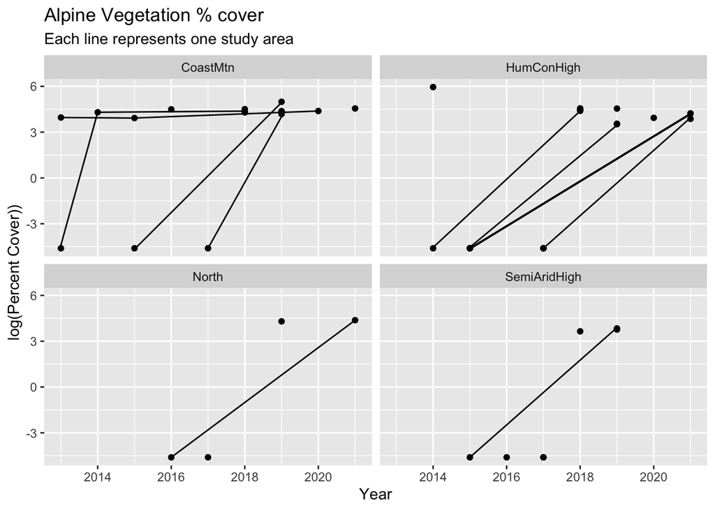

Figure 6: Summary plot of the data. The data is analyzed on the logarithmic scale.

Again, lots of transects with 0% total cover which is incorrect.